# R Notebook

```r
#install.packages(c("ggrepel", "dplyr", "gridExtra", "grid", "lattice", "ggpubr", "umap", "ggfortify", "magick", "BiocManager", "readxl", "rmarkdown", "tibble", "rlist"))
#BiocManager::install(c('DESeq2', 'ComplexHeatmap', 'biomaRt', 'fgsea', 'msigdbr'))

library(rmarkdown)
library(readxl)
library(DESeq2)
library(ComplexHeatmap)
library(circlize)
library(dendsort)
library(biomaRt)
library(fgsea)
library(data.table)
library(msigdbr)
library(ggrepel)
library(dplyr)
library(gridExtra)
library(grid)
library(lattice)
library(ggpubr)
library(umap)
library(ggfortify)
library(magick)
library(tibble)
library(rlist)
library(outliers)
```

```r
# ensembl=useMart("ensembl")
# ensembl = useDataset("hsapiens_gene_ensembl",mart=ensembl)
# attributes = listAttributes(ensembl)
# ensids=rownames(count_data_deseq)
# ens2gene = getBM(attributes=c('external_gene_name','ensembl_gene_id','gene_biotype','entrezgene_id', 'description'),
#                  filters = 'ensembl_gene_id',
#                  values = ensids,
#                  mart = ensembl)
# ens2gene = ens2gene[!duplicated(ens2gene$ensembl_gene_id),]
# rownames(ens2gene) = ens2gene$ensembl_gene_id
# head(ens2gene)
# saveRDS(ens2gene, "ens2gene.RDS")
```

```r
count_data = readRDS('data/Raw_RNASeq_Data.RDS')
ens2gene = readRDS("data/ens2gene.RDS")
meta_data = data.frame(read.csv('data/COVIRS_metadata.csv', header = TRUE))
```

### 0. Introduction

The COVIRS dataset allows a complex, deep analysis of vaccine response. [Ryan et al. (2022)](https://www.medrxiv.org/content/10.1101/2022.09.22.22280180v1) found a few variables associated with individual symptoms (e.g., lower TFNa and chills after second dose of Pfizer), but only tested presence/absence of individual symptoms for associations.

Here, I sought to take this line of thinking further by finding groups of participants based on all symptoms, comparing gene expression between the two groups after the second dose of Pfizer (V2), and seeing if any differences can be detected between the same groups at V0 (i.e., before vaccination).

Briefly, two groups were identified - symptomatic and asymptomatic. At V2 (28 days after the second vaccine dose), CNOT7 is significantly underexpressed in the symptomatic group. GSEA found cell signature differences using blood transcriptional modules from [Li et al. (2014)](https://pubmed.ncbi.nlm.nih.gov/24336226/), identifying NK and B cells as more active in the symptomatic group, partly confirmed by a statistically significant lower B cell count from flow cytometry. At V0 (prior to the first vaccine dose), cell composition differences were unclear, but a few individual genes were significantly differentially expressed, including RNU1-4, an snRNA with unclear function that was overexpressed in the asymptomatic group.

### 1. Defining patient groups based on symptoms

Data from Pfizer-vaccinated participants only (i.e., first and second dose) was used in this analysis due to the greater abundance and variety of V2 symptoms, and due to the small number of AstraZeneca-vaccinated participants.

```r
meta_data = meta_data[meta_data$Timepoint == 'V2A' & meta_data$First.Second.vaccine == 'BNT162b2', ]
```

In the clustered heatmap below we can see that there are broadly two groups of participants - those with V2 fatigue, headache, myalgia, and chills (right half), and those without (left half).

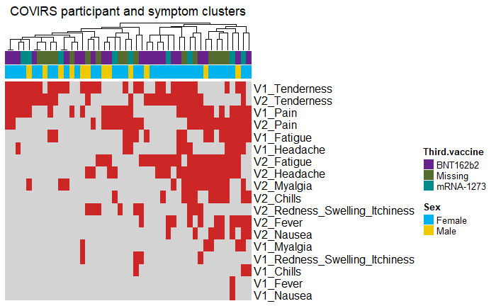

```r
plot = data.frame(subset(meta_data, select = -c(id, Participant.ID, Run, SAGC_ID, First.Second.vaccine, Third.vaccine, Sex, Timepoint)))
col_dend = dendsort(hclust(dist(plot)))
ha_participants = HeatmapAnnotation(df = meta_data[ ,c('Third.vaccine', 'Sex')], col = list(Third.vaccine = c('mRNA-1273' = 'darkcyan', 'BNT162b2' = 'darkorchid4', 'Missing' = 'darkolivegreen'), Sex = c('Male' = 'gold2', 'Female' = 'deepskyblue2')), show_annotation_name = FALSE)
Heatmap(as.matrix(t(plot)), show_row_names = TRUE, show_column_names = FALSE, cluster_rows = TRUE, cluster_columns = col_dend, show_row_dend = FALSE, top_annotation = ha_participants, show_heatmap_legend = FALSE, col = c('lightgrey', 'firebrick3'), column_title = 'COVIRS participant and symptom clusters')
```

```r
rm(plot); rm(ha_participants); rm(col_dend);
```

The below two plots are UMAPs of participants by symptoms (each point represents one person). We can see that there are two clusters within the emerging symptomatic group: the top cluster centered approximately at (-0.5, 2.5) and the bottom cluster, centred approximately at (-1, -5). The point labels showing total number of symptoms suggest that they differ in the presence (top cluster) or absence (bottom cluster) of fever and nausea in addition to the other systemic symptoms at V2. This heterogeneity was not accounted for in the differential expression (DE) analysis to follow due to the low sample size and hence low statistical power to confirm differences between these groups.

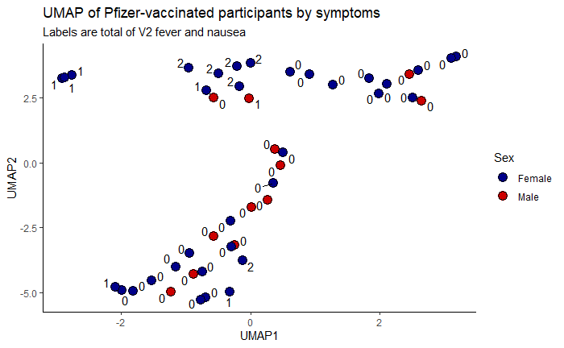

```r
custom.config = umap.defaults
custom.config$random_state = 1
custom.config$n_neighbors = 3
plot = meta_data
umap = umap(as.matrix(apply(subset(plot, select = -c(id, Participant.ID, Run, SAGC_ID, Timepoint, First.Second.vaccine, Third.vaccine, Sex)), 2, as.numeric)), config = custom.config)
umap = data.frame(umap$layout)
plot$UMAP1 = umap$X1
plot$UMAP2 = umap$X2
rm(umap)
ggplot(plot, aes(x = UMAP1, y = UMAP2, fill = Sex, label = apply(subset(plot, select = c(V2_Fever, V2_Nausea)) == 1, 1, sum))) + geom_point(shape = 21, size = 4) +
  scale_fill_manual(values = c(Male = "red3", Female = "blue4")) + theme_classic() + geom_text_repel() +
  ggtitle('UMAP of Pfizer-vaccinated participants by symptoms', subtitle = 'Labels are total of V2 fever and nausea'); rm (plot)
```

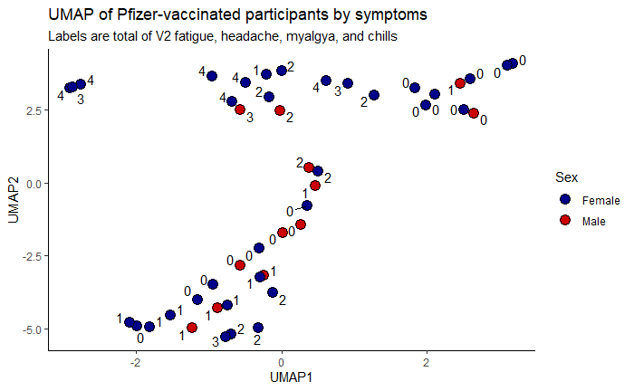

```r
plot = meta_data
umap = umap(as.matrix(apply(subset(plot, select = -c(id, Participant.ID, Run, SAGC_ID, Timepoint, First.Second.vaccine, Third.vaccine, Sex)), 2, as.numeric)), config = custom.config)
umap = data.frame(umap$layout)
plot$UMAP1 = umap$X1
plot$UMAP2 = umap$X2
rm(umap)
ggplot(plot, aes(x = UMAP1, y = UMAP2, fill = Sex, label = apply(subset(plot, select = c(V2_Fatigue, V2_Headache, V2_Myalgia, V2_Chills)) == 1, 1, sum))) + geom_point(shape = 21, size = 4) +
  scale_fill_manual(values = c(Male = "red3", Female = "blue4")) + theme_classic() + geom_text_repel() +
  ggtitle('UMAP of Pfizer-vaccinated participants by symptoms', subtitle = 'Labels are total of V2 fatigue, headache, myalgya, and chills'); rm (plot)
```

The UMAP below is a transpose of the above: each point here is a symptom. Immediately, we can see that local symptoms (pain, tenderness, and possibly redness/swelling/itchiness) cluster strongly together at both timepoints and are separated from the systemic symptoms. Note that nausea clusters together with the other systemic symptoms.

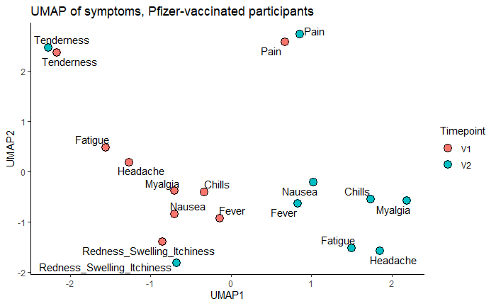

```r
plot = data.frame(t(subset(meta_data, select = -c(id, Participant.ID, Run, SAGC_ID, Timepoint, First.Second.vaccine, Third.vaccine, Sex))))
umap = umap(as.matrix(apply(plot, 2, as.numeric)), config = custom.config); umap = data.frame(umap$layout)
plot$UMAP1 = umap$X1; plot$UMAP2 = umap$X2; rm(umap)
plot$Timepoint = ifelse(grepl('V1_', rownames(plot)), 'V1', 'V2')
plot$Symptom = gsub('V1_', '', rownames(plot)); plot$Symptom = gsub('V2_', '', plot$Symptom)
ggplot(plot, aes(x = UMAP1, y = UMAP2, label = Symptom, fill = Timepoint)) + geom_point(shape = 21, size = 4) + geom_text_repel() + theme_classic() + ggtitle('UMAP of symptoms, Pfizer-vaccinated participants')
```

```r
rm(custom.config); rm(plot)
```

Finally, we can define comparison groups for DE analysis. Having 3 or more of V2 Fatigue, Headache, Myalgia, Chills, Fever, or Nausea (systemic symptoms) defines the symptomatic group (n = 16, 2 males). Having no V2 systemic symptoms and 2 or less of V2 Pain, Tenderness, or Redness/swelling/itchiness defines the asymptomatic group (n = 16, 4 males). There were many more females than males in the COVIRS dataset, so this is not suprising, and Fisher's exact test (not shown) indicates that this group composition is consistent with equal distribution (p = 0.614)

```r
test = meta_data[apply(subset(meta_data, select = c(V2_Fatigue, V2_Headache, V2_Myalgia, V2_Chills, V2_Fever, V2_Nausea)) == 1, 1, sum) >= 3, ]; test$Group = "Symptomatic"
control = subset(meta_data[apply(meta_data[, 18:ncol(meta_data)] == 1, 1, sum) <= 2, ], V2_Fatigue == 0 & V2_Myalgia == 0 & V2_Chills == 0 & V2_Headache == 0 & V2_Fever == 0 & V2_Nausea == 0); control$Group = "Asymptomatic"
```

```r
meta_data = rbind(test, control); rm(test); rm(control)
count_data = count_data[, colnames(count_data) %in% meta_data$id]; meta_data = meta_data[order(meta_data$id), ]
count_data = count_data[, order(colnames(count_data))]; count_data = count_data[rownames(ens2gene), ]
count_data = data.frame(cbind(ensgene = rownames(count_data), count_data))
rownames(count_data) = NULL; rownames(meta_data) = NULL
```

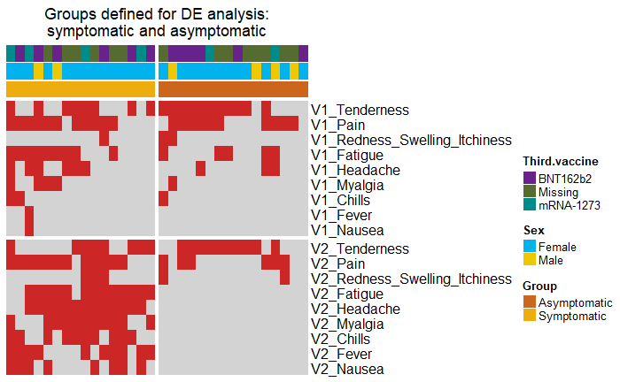

```r
plot = as.matrix(meta_data[, 10:ncol(meta_data) - 1])
ha_participants = HeatmapAnnotation(df = meta_data[, c('Third.vaccine', 'Sex', 'Group')], col = list(Group = c('Asymptomatic' = 'chocolate3', 'Symptomatic' = 'darkgoldenrod2'), Third.vaccine = c('mRNA-1273' = 'darkcyan', 'BNT162b2' = 'darkorchid4', 'Missing' = 'darkolivegreen'), Sex = c('Male' = 'gold2', 'Female' = 'deepskyblue2')), show_annotation_name = FALSE)
Heatmap(t(plot), column_split = meta_data$Group, row_order = c("V1_Tenderness", "V1_Pain", "V1_Redness_Swelling_Itchiness", "V1_Fatigue", "V1_Headache", "V1_Myalgia", "V1_Chills", "V1_Fever", "V1_Nausea", "V2_Tenderness", "V2_Pain", "V2_Redness_Swelling_Itchiness", "V2_Fatigue", "V2_Headache", "V2_Myalgia", "V2_Chills", "V2_Fever", "V2_Nausea"), cluster_columns = TRUE, show_row_dend = FALSE, show_column_dend = FALSE, column_dend_side = 'top', col = c('lightgrey', 'firebrick3'), top_annotation = ha_participants, show_column_names = FALSE, show_heatmap_legend = FALSE, row_split = grepl('V2_', rownames(t(plot))), row_title = NULL, column_title = 'Groups defined for DE analysis:\nsymptomatic and asymptomatic'); rm(plot)
```

### 2. Antibodies and T cell responses

Another important motivator for this study is that the groups do not differ significantly in COVID antibody titres or T cell responses. This means that the symptoms observed do not correlate with common measures of vaccince effectiveness. Hence, this further motivates a DE analysis of the two groups.

```r
antibody_data = read.csv('data/antibodies.csv')
antibody_data = subset(antibody_data, Patient %in% meta_data$Participant.ID); meta_anti = meta_data[meta_data$Participant.ID %in% antibody_data$Patient, ]; antibody_data$Group = meta_anti$Group; rm(meta_anti)
```

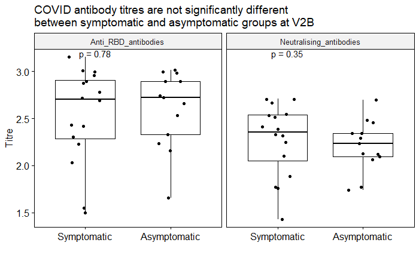

```r
ggboxplot(antibody_data, x = 'Group', y = 'Titre', add = 'jitter', facet.by = 'Antibody.type') + stat_compare_means(label = "p.format") + xlab('') + ggtitle('COVID antibody titres are not significantly different\nbetween symptomatic and asymptomatic groups at V2B')
```

```r
tcell_data = read.csv('data/tcells.csv')
tcell_data = subset(tcell_data, Patient_ID %in% meta_data$Participant.ID); meta_tcell = meta_data[meta_data$Participant.ID %in% tcell_data$Patient_ID, ]; tcell_data$Group = meta_tcell$Group; rm(meta_tcell); tcell_data$Value = log10(tcell_data$Value)
```

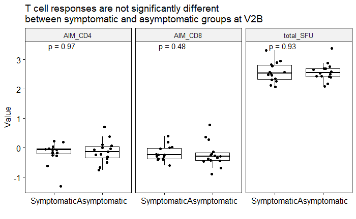

```r
ggboxplot(tcell_data, x = 'Group', y = 'Value', add = 'jitter', facet.by = 'Type') + stat_compare_means(label = "p.format") + xlab('') + ggtitle('T cell responses are not significantly different\nbetween symptomatic and asymptomatic groups at V2B')
```

```r
rm(antibody_data); rm(ha_participants); rm(tcell_data)
```

### 3. Flow cytometry

At V2, blood B cell count is significantly lower in the symptomatic group. This is exaplained by B cells migrating to the spleen to complete their development.

```r
flow = read.csv('data/COVIRS_flow_data_20230202.csv'); flow = subset(flow, Patient %in% meta_data$Participant.ID & Timepoint == 'V2A'); meta_flow = subset(meta_data, Participant.ID %in% flow$Patient); flow = flow[order(flow$Patient), ]; flow$Total = rowSums(flow[, 5:ncol(flow)-1]); flow$Group = meta_flow$Group;
```

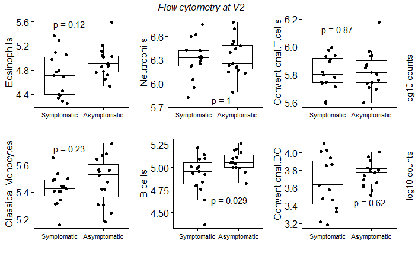

```r
flow_log = log10(flow[, 5:ncol(flow) - 1]); flow_log$Group = meta_flow$Group

plot1 = ggboxplot(flow_log, x = 'Group', y = colnames(flow_log)[1], add = 'jitter') + stat_compare_means(label = "p.format", label.x = 1, label.y = 5.5) + xlab('') + theme(axis.text.x = element_text(size = 8))
plot2 = ggboxplot(flow_log, x = 'Group', y = colnames(flow_log)[2], add = 'jitter') + stat_compare_means(label = "p.format", label.x = 1.5, label.y = 5.75) + xlab('') + theme(axis.text.x = element_text(size = 8))
plot3 = ggboxplot(flow_log, x = 'Group', y = colnames(flow_log)[3], add = 'jitter') + stat_compare_means(label = "p.format", label.x = 1, label.y = 6.1) + xlab('') + theme(axis.text.x = element_text(size = 8))
plot6 = ggboxplot(flow_log, x = 'Group', y = colnames(flow_log)[6], add = 'jitter') + stat_compare_means(label = "p.format", label.x = 1, label.y = 5.7) + xlab('') + theme(axis.text.x = element_text(size = 8))
plot9 = ggboxplot(flow_log, x = 'Group', y = colnames(flow_log)[9], add = 'jitter') + stat_compare_means(label = "p.format", label.x = 1.5, label.y = 4.6) + xlab('') + theme(axis.text.x = element_text(size = 8))
plot11 = ggboxplot(flow_log, x = 'Group', y = colnames(flow_log)[11], add = 'jitter') + stat_compare_means(label = "p.format", label.x = 1.75, label.y = 3.4) + xlab('') + theme(axis.text.x = element_text(size = 8))
grid.arrange(plot1, plot2, plot3, plot6, plot9, plot11, ncol = 3, top = textGrob('Flow cytometry at V2', gp = gpar(fontface = 3)), right = textGrob('log10 counts                    log10 counts', rot = 90, gp = gpar(fontsize = 11)))
```

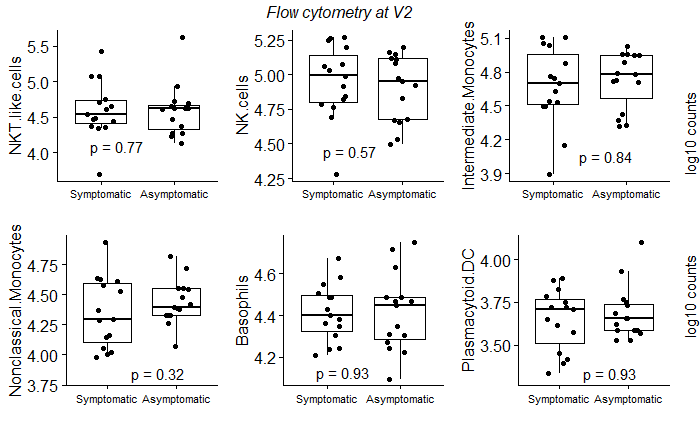

```r
plot4 = ggboxplot(flow_log, x = 'Group', y = colnames(flow_log)[4], add = 'jitter') + stat_compare_means(label = "p.format", label.x = 1, label.y = 4.0) + xlab('') + theme(axis.text.x = element_text(size = 8))
plot5 = ggboxplot(flow_log, x = 'Group', y = colnames(flow_log)[5], add = 'jitter') + stat_compare_means(label = "p.format", label.x = 1, label.y = 4.4) + xlab('') + theme(axis.text.x = element_text(size = 8))
plot7 = ggboxplot(flow_log, x = 'Group', y = colnames(flow_log)[7], add = 'jitter') + stat_compare_means(label = "p.format", label.x = 1.5, label.y = 4.0) + xlab('') + theme(axis.text.x = element_text(size = 8))
plot8 = ggboxplot(flow_log, x = 'Group', y = colnames(flow_log)[8], add = 'jitter') + stat_compare_means(label = "p.format", label.x = 1.5, label.y = 3.8) + xlab('') + theme(axis.text.x = element_text(size = 8))
plot10 = ggboxplot(flow_log, x = 'Group', y = colnames(flow_log)[10], add = 'jitter') + stat_compare_means(label = "p.format", label.x = 1, label.y = 4.1) + xlab('') + theme(axis.text.x = element_text(size = 8))
plot12 = ggboxplot(flow_log, x = 'Group', y = colnames(flow_log)[12], add = 'jitter') + stat_compare_means(label = "p.format", label.x = 1.5, label.y = 3.3) + xlab('') + theme(axis.text.x = element_text(size = 8))
grid.arrange(plot4, plot5, plot7, plot8, plot10, plot12, ncol = 3, top = textGrob('Flow cytometry at V2', gp = gpar(fontface = 3)), right = textGrob('log10 counts                    log10 counts', rot = 90, gp = gpar(fontsize = 11)))
```

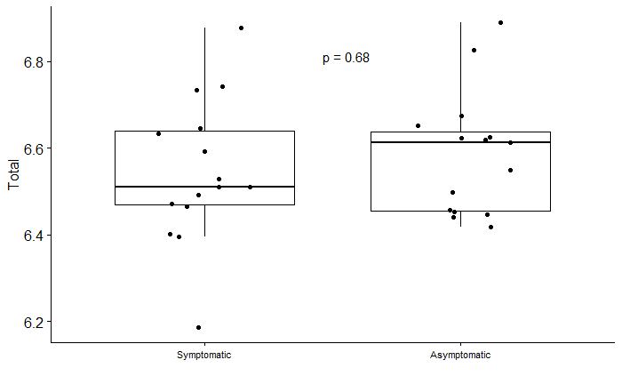

```r
ggboxplot(flow_log, x = 'Group', y = 'Total', add = 'jitter') + stat_compare_means(label = "p.format", label.x = 1.5, label.y = 6.8) + xlab('') + theme(axis.text.x = element_text(size = 8))
```

```r
flow = read.csv('data/COVIRS_flow_data_20230202.csv'); flow = subset(flow, Patient %in% meta_data$Participant.ID & Timepoint == 'V0'); meta_flow = subset(meta_data, Participant.ID %in% flow$Patient); flow = flow[order(flow$Patient), ]; flow$Total = rowSums(flow[, 5:ncol(flow)-1]); flow$Group = meta_flow$Group
```

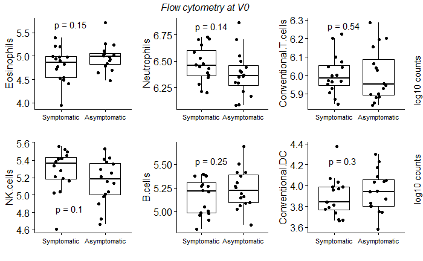

```r
flow_log = log10(flow[, 5:ncol(flow) - 1]); flow_log$Group = meta_flow$Group

plot1 = ggboxplot(flow_log, x = 'Group', y = colnames(flow_log)[1], add = 'jitter') + stat_compare_means(label = "p.format", label.x = 1, label.y = 5.6) + xlab('') + theme(axis.text.x = element_text(size = 8))
plot2 = ggboxplot(flow_log, x = 'Group', y = colnames(flow_log)[2], add = 'jitter') + stat_compare_means(label = "p.format", label.x = 1, label.y = 6.8) + xlab('') + theme(axis.text.x = element_text(size = 8))
plot3 = ggboxplot(flow_log, x = 'Group', y = colnames(flow_log)[3], add = 'jitter') + stat_compare_means(label = "p.format", label.x = 1, label.y = 6.25) + xlab('') + theme(axis.text.x = element_text(size = 8))
plot5 = ggboxplot(flow_log, x = 'Group', y = colnames(flow_log)[5], add = 'jitter') + stat_compare_means(label = "p.format", label.x = 1, label.y = 4.8) + xlab('') + theme(axis.text.x = element_text(size = 8))
plot9 = ggboxplot(flow_log, x = 'Group', y = colnames(flow_log)[9], add = 'jitter') + stat_compare_means(label = "p.format", label.x = 1, label.y = 5.5) + xlab('') + theme(axis.text.x = element_text(size = 8))
plot11 = ggboxplot(flow_log, x = 'Group', y = colnames(flow_log)[11], add = 'jitter') + stat_compare_means(label = "p.format", label.x = 1, label.y = 4.2) + xlab('') + theme(axis.text.x = element_text(size = 8))
grid.arrange(plot1, plot2, plot3, plot5, plot9, plot11, ncol = 3, top = textGrob('Flow cytometry at V0', gp = gpar(fontface = 3)), right = textGrob('log10 counts                    log10 counts', rot = 90, gp = gpar(fontsize = 11)))
```

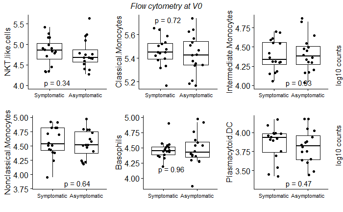

```r
plot4 = ggboxplot(flow_log, x = 'Group', y = colnames(flow_log)[4], add = 'jitter') + stat_compare_means(label = "p.format", label.x = 1, label.y = 4.0) + xlab('') + theme(axis.text.x = element_text(size = 8))
plot6 = ggboxplot(flow_log, x = 'Group', y = colnames(flow_log)[6], add = 'jitter') + stat_compare_means(label = "p.format", label.x = 1, label.y = 5.7) + xlab('') + theme(axis.text.x = element_text(size = 8))
plot7 = ggboxplot(flow_log, x = 'Group', y = colnames(flow_log)[7], add = 'jitter') + stat_compare_means(label = "p.format", label.x = 1.5, label.y = 4.0) + xlab('') + theme(axis.text.x = element_text(size = 8))
plot8 = ggboxplot(flow_log, x = 'Group', y = colnames(flow_log)[8], add = 'jitter') + stat_compare_means(label = "p.format", label.x = 1.5, label.y = 3.8) + xlab('') + theme(axis.text.x = element_text(size = 8))
plot10 = ggboxplot(flow_log, x = 'Group', y = colnames(flow_log)[10], add = 'jitter') + stat_compare_means(label = "p.format", label.x = 1, label.y = 4.1) + xlab('') + theme(axis.text.x = element_text(size = 8))
plot12 = ggboxplot(flow_log, x = 'Group', y = colnames(flow_log)[12], add = 'jitter') + stat_compare_means(label = "p.format", label.x = 1.5, label.y = 3.3) + xlab('') + theme(axis.text.x = element_text(size = 8))
grid.arrange(plot4, plot6, plot7, plot8, plot10, plot12, ncol = 3, top = textGrob('Flow cytometry at V0', gp = gpar(fontface = 3)), right = textGrob('log10 counts                    log10 counts', rot = 90, gp = gpar(fontsize = 11)))
```

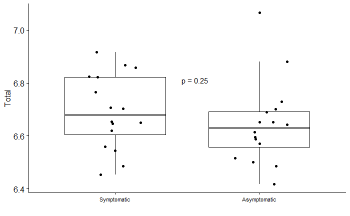

```r
ggboxplot(flow_log, x = 'Group', y = 'Total', add = 'jitter') + stat_compare_means(label = "p.format", label.x = 1.5, label.y = 6.8) + xlab('') + theme(axis.text.x = element_text(size = 8))
```

```r
rm(flow); rm(meta_flow); rm(flow_log); rm(plot4); rm(plot6); rm(plot7); rm(plot8); rm(plot10); rm(plot12); rm(plot1); rm(plot2); rm(plot3); rm(plot5); rm(plot9); rm(plot11)
```

### 4. V2 gene set enrichment analysis

Before proceeding, a quick quality check of the data and the analysis is to plot XIST expression by sex. As expected, it is not expressed in males.

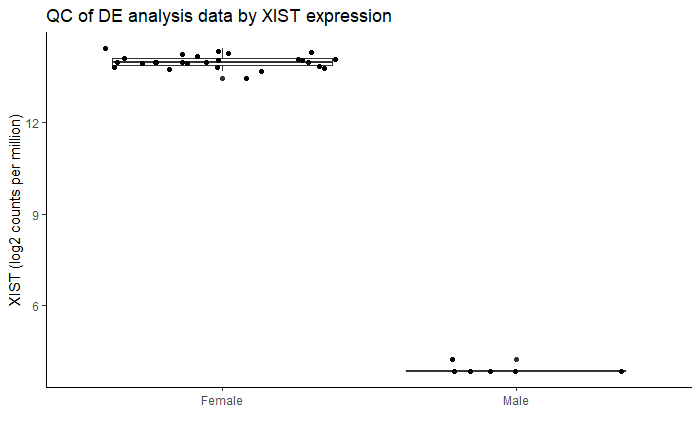

```r
dds = DESeqDataSetFromMatrix(countData = count_data,
                              colData = meta_data,
                              design = ~ Sex, tidy = TRUE)
vsd = vst(dds, blind = FALSE); vsd.df = assay(vsd)
vsd.df = data.frame(t(vsd.df))
vsd.df$Group = meta_data$Group; vsd.df$Sex = meta_data$Sex
ggplot(vsd.df, aes(x = Sex, y = vsd.df[, 'ENSG00000229807'])) + geom_boxplot() + geom_jitter() + ylab('XIST (log2 counts per million)') + theme_classic() + xlab('') + ggtitle('QC of DE analysis data by XIST expression')
```

Only genes with 100 read counts or more in at least 4 samples (i.e., participants) were kept from the counts matrix, and [DESeq2](https://bioconductor.org/packages/release/bioc/html/DESeq2.html) was used to find differences between the groups while controlling for differences due to sex.

```r
dds = DESeqDataSetFromMatrix(countData = count_data,
                              colData = meta_data,
                              design = ~ Group + Sex, tidy = TRUE)
```

```r
vsd = vst(dds, blind = FALSE); vsd.df = assay(vsd)
write.csv(vsd.df, file = 'results/counts_norm_v2.csv', row.names = TRUE)
```

```r
keep = rowSums(counts(dds)>100) >= 4; dds = dds[keep, ]; dds = DESeq(dds)
```

```
-- replacing outliers and refitting for 20 genes
-- DESeq argument 'minReplicatesForReplace' = 7
-- original counts are preserved in counts(dds)
```

```r
res = results(dds, contrast = c("Group", "Symptomatic", "Asymptomatic")); res = res[order(res$padj, decreasing = FALSE), ]
res; summary(res)
```

```
log2 fold change (MLE): Group Symptomatic vs Asymptomatic
Wald test p-value: Group Symptomatic vs Asymptomatic
DataFrame with 11403 rows and 6 columns
                 baseMean log2FoldChange     lfcSE         stat      pvalue      padj
                <numeric>      <numeric> <numeric>    <numeric>   <numeric> <numeric>
ENSG00000198791 1120.7692      -0.183659 0.0388160     -4.73151 2.22853e-06  0.025403
ENSG00000285756  750.6775       0.923212 0.2158807      4.27649 1.89861e-05  0.108211
ENSG00000152689  499.4901       0.774705 0.1856994      4.17182 3.02170e-05  0.110068
ENSG00000169607   73.5999       0.560044 0.1360796      4.11556 3.86239e-05  0.110068
ENSG00000167670  653.8076       0.322582 0.0796486      4.05006 5.12048e-05  0.116737
...                   ...            ...       ...          ...         ...       ...
ENSG00000089048   319.702    3.87279e-06 0.0633473  6.11359e-05    0.999951  0.999982
ENSG00000207005  1044.569   -1.88696e+00 0.6090192 -3.09836e+00          NA        NA
ENSG00000184500   222.258   -1.78817e-01 0.3468684 -5.15518e-01          NA        NA
ENSG00000078114    25.276   -1.59377e+00 0.5449411 -2.92467e+00          NA        NA
ENSG00000107566   470.830    8.18822e-03 0.2855543  2.86748e-02          NA        NA

out of 11403 with nonzero total read count
adjusted p-value < 0.1
LFC > 0 (up)       : 0, 0%
LFC < 0 (down)     : 1, 0.0088%
outliers [1]       : 4, 0.035%
low counts [2]     : 0, 0%
(mean count < 25)
[1] see 'cooksCutoff' argument of ?results
[2] see 'independentFiltering' argument of ?results
```

```r
res.df = data.frame(res); res.df = data.frame(res.df, ens2gene[rownames(res.df), ])
write.csv(res.df, file = 'results/res_deseq_v2.csv', row.names = TRUE)
rm(keep)
```

A few genes with positive log2 fold change (i.e., overexpressed in the symptomatic group) are approaching significance (padj <= 0.1). Of genes with negative log2 fold change, only CNOT7 was significant.

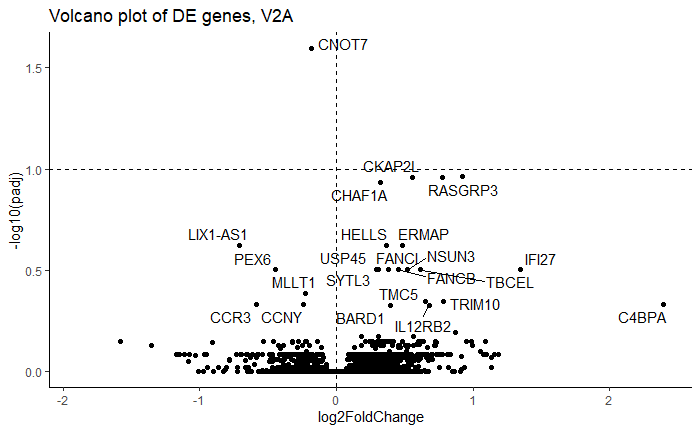

```r
plot = subset(res.df, padj < 0.8)
ggplot(res.df, aes(x = log2FoldChange, y = -log10(padj))) + geom_point() +
  geom_hline(yintercept = -log10(0.1), linetype = 2) + geom_vline(xintercept = 0, linetype = 2) +
  theme_classic() + geom_text_repel(max.overlaps = 13, data = subset(plot, -log10(padj) > 0.2), aes(x = log2FoldChange, y = -log10(padj), label = external_gene_name)) + ggtitle("Volcano plot of DE genes, V2A"); rm(plot)
```

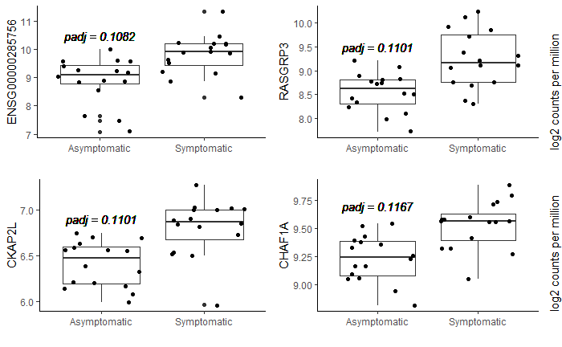

```r
plot = rbind(filter(res.df, log2FoldChange > 0)[1:4, ], filter(res.df, log2FoldChange < 0)[1:2, ])
vsd.df = data.frame(t(vsd.df)); vsd.df$Group = meta_data$Group; vsd.df$Sex = meta_data$Sex

plot1 = ggplot(vsd.df, aes(x = Group, y = vsd.df[, rownames(plot)[1]])) + geom_boxplot() + geom_jitter() + ylab(res.df[rownames(plot)[1], 'ensembl_gene_id']) + geom_text(aes(x = 1, y = 10.5, fontface = 3), label = paste0('padj = ', as.character(round(res.df[rownames(plot)[1], 'padj'], 4)))) + theme_classic() + xlab('')
plot2 = ggplot(vsd.df, aes(x = Group, y = vsd.df[, rownames(plot)[2]])) + geom_boxplot() + geom_jitter() + ylab(res.df[rownames(plot)[2], 'external_gene_name']) + geom_text(aes(x = 1, y = 9.5, fontface = 3), label = paste0('padj = ', as.character(round(res.df[rownames(plot)[2], 'padj'], 4)))) + theme_classic() + xlab('')
plot3 = ggplot(vsd.df, aes(x = Group, y = vsd.df[, rownames(plot)[3]])) + geom_boxplot() + geom_jitter() + ylab(res.df[rownames(plot)[3], 'external_gene_name']) + geom_text(aes(x = 1, y = 6.9, fontface = 3), label = paste0('padj = ', as.character(round(res.df[rownames(plot)[3], 'padj'], 4)))) + theme_classic() + xlab('')
plot4 = ggplot(vsd.df, aes(x = Group, y = vsd.df[, rownames(plot)[4]])) + geom_boxplot() + geom_jitter() + ylab(res.df[rownames(plot)[4], 'external_gene_name']) + geom_text(aes(x = 1, y = 9.7, fontface = 3), label = paste0('padj = ', as.character(round(res.df[rownames(plot)[4], 'padj'], 4)))) + theme_classic() + xlab('')
plot5 = ggplot(vsd.df, aes(x = Group, y = vsd.df[, rownames(plot)[5]])) + geom_boxplot() + geom_jitter() + ylab(res.df[rownames(plot)[5], 'external_gene_name']) + geom_text(aes(x = 2, y = 10.25, fontface = 3), label = paste0('padj = ', as.character(round(res.df[rownames(plot)[5], 'padj'], 4)))) + theme_classic() + xlab('')
plot6 = ggplot(vsd.df, aes(x = Group, y = vsd.df[, rownames(plot)[6]])) + geom_boxplot() + geom_jitter() + ylab(res.df[rownames(plot)[6], 'external_gene_name']) + geom_text(aes(x = 2, y = 7.1, fontface = 3), label = paste0('padj = ', as.character(round(res.df[rownames(plot)[6], 'padj'], 4)))) + theme_classic() + xlab('')
grid.arrange(plot1, plot2, plot3, plot4, ncol = 2, right = textGrob('log2 counts per million              log2 counts per million', rot = 90, gp = gpar(fontsize = 11)))
```

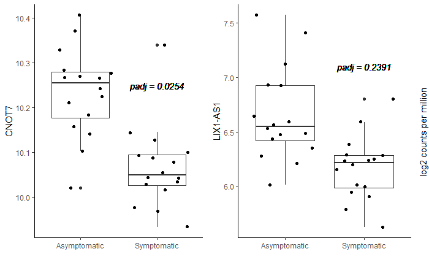

```r
grid.arrange(plot5, plot6, ncol = 2, right = textGrob('log2 counts per million', rot = 90, gp = gpar(fontsize = 11)))
```

```r
vsd.df$Sex = NULL; vsd.df$Group = NULL; vsd.df = data.frame(t(vsd.df))
rm(plot); rm(plot1); rm(plot2); rm(plot3); rm(plot4); rm(plot5); rm(plot6)
```

CNOT7 depletion was reported by [Ren et al. (2020)](https://www.ncbi.nlm.nih.gov/pmc/articles/PMC7193174/) and [Guo et al. (2019)](https://pesquisa.bvsalud.org/portal/resource/pt/wpr-744830) to reduce TGF beta 1 production in liver cancer cells and, importantly, increase IFN gamma secretion by NK cells. Are these cells more active in the symptomatic participants? To answer this and other questions about the immune response, and to find expression differences in groups of genes rather than individual genes, a gene set enrichment analysis was conducted.

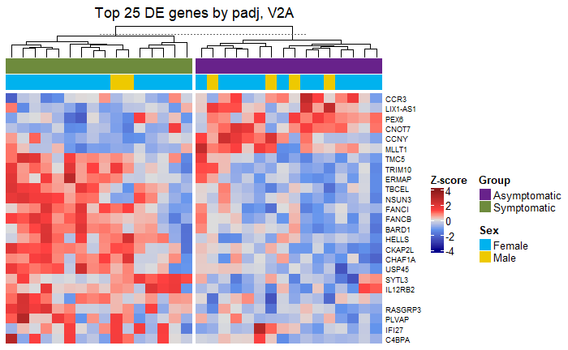

```r
ha_top = HeatmapAnnotation(df = meta_data[, c('Group', 'Sex')], col = list(Group = c('Symptomatic' = 'darkolivegreen4', 'Asymptomatic' = 'darkorchid4'), Sex = c('Male' = 'gold2', 'Female' = 'deepskyblue2')), show_annotation_name = FALSE)
zzz = t(scale(t(vsd.df[rownames(res.df[1:25, ]), ]))); zzz = pmin(pmax(zzz, -3), 3); rownames(zzz) =  res.df[rownames(zzz), 'external_gene_name']
Heatmap(zzz, show_row_names = TRUE, show_column_names = FALSE, cluster_rows = TRUE, cluster_columns = TRUE, show_row_dend = FALSE, top_annotation = ha_top, heatmap_legend_param = list(title = "Z-score"), col = colorRamp2(c(-4, -1.25, 0, 1.25, 4), c("darkblue", "cornflowerblue", "gainsboro", "brown1", "firebrick4")), row_names_gp = gpar(fontsize = 7), column_title = 'Top 25 DE genes by padj, V2A', column_split = meta_data$Group)
```

```r
rm(ha_top); rm(zzz)
```

As for TNFa signalling, scanning the Human Protein Atlas for signle-cell expression of [NFKB1](https://www.proteinatlas.org/ENSG00000109320-NFKB1/single+cell+type) and [TNF](https://www.proteinatlas.org/ENSG00000232810-TNF/single+cell+type) in B cells suggests that these proteins are not overexpressed in this cell type compared to other immune cells, and hence the decrease in TNFa pathway gene expression is likely not an artefact.

An important note for interpreting volcano plots of gene sets: most of the time, individual genes are *not* differentially expressed with a sufficient padj (whose value is very low in most cases). These plots are shown to illustrate the very different shapes of the data that are nonetheless assigned similar normalised expression scores and padj values by fgsea.

```r
ranks <- res.df %>%
  as_tibble() %>%
  dplyr::select(external_gene_name, log2FoldChange) %>%
  na.omit() %>%
  distinct() %>%
  group_by(external_gene_name) %>%
  summarize(log2FoldChange=mean(log2FoldChange))
ranks <- deframe(ranks)
```

```r
msig.df = as.data.frame(msigdbr(species = "Homo sapiens", category = "H"))
msigDB = by(msig.df$gene_symbol, msig.df$gs_name, function(x) as.character(x))
names(msigDB) = gsub('HALLMARK_', '', names(msigDB))
fgseaRes = fgsea(pathways = msigDB, stats = ranks, nproc = 1); fgseaRes = fgseaRes[order(fgseaRes$padj, decreasing = FALSE), ]
write.csv(subset(fgseaRes, select = -c(leadingEdge)), file = 'results/fgseaRes_H_v2.csv', row.names = FALSE)
```

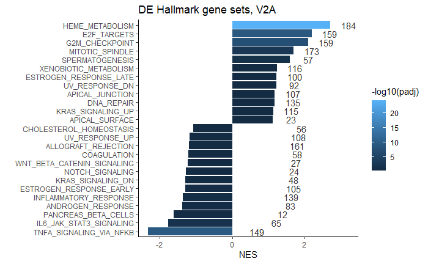

```r
ggplot(fgseaRes[1:25, ], aes(y = reorder(pathway, NES), x = NES, fill = -log10(padj), label = size)) +
  geom_col() + geom_text(color = 'gray20', nudge_x = ifelse(fgseaRes$NES > 0, 0.5, 3)) +
  ylab('') + theme_classic() + ggtitle('DE Hallmark gene sets, V2A')
```

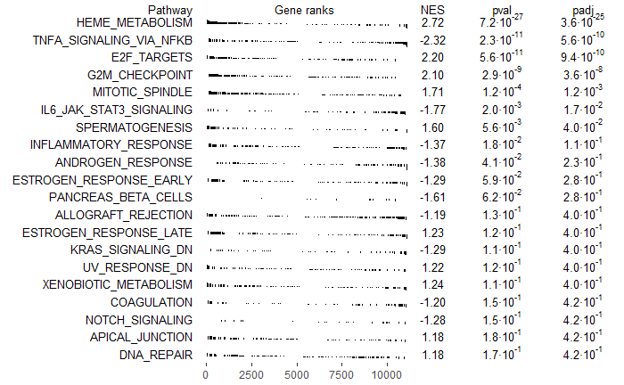

```r
plotGseaTable(msigDB[fgseaRes[1:20, ][, pathway]], ranks, fgseaRes[1:20, ], gseaParam = 0.5, colwidths = c(3, 3, 0.8, 1.2, 1.2), pathwayLabelStyle = list(size = 10), headerLabelStyle = list(size = 10), valueStyle = list(size = 10))
```

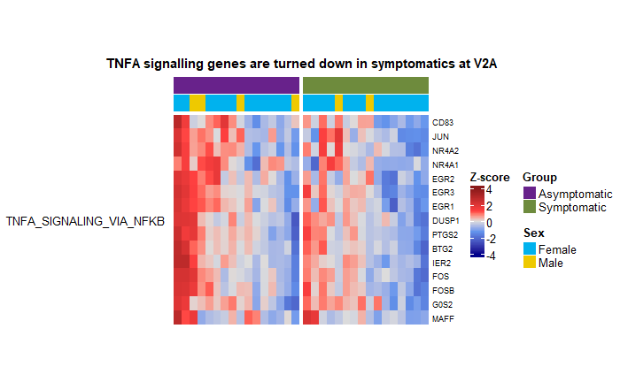

```r
res.df = res.df[order(res.df$log2FoldChange, decreasing = FALSE), ]
ha_top = HeatmapAnnotation(df = meta_data[, c('Group', 'Sex')], col = list(Group = c('Symptomatic' = 'darkolivegreen4', 'Asymptomatic' = 'darkorchid4'), Sex = c('Male' = 'gold2', 'Female' = 'deepskyblue2')), show_annotation_name = FALSE)
plot2 = vsd.df[rownames(subset(res.df, external_gene_name %in% msigDB[[fgseaRes[[2, 'pathway']]]] & log2FoldChange < 0))[1:15], ]
zzz = t(scale(t(plot2))); zzz = pmin(pmax(zzz, -3), 3); rownames(zzz) =  res.df[rownames(zzz), 'external_gene_name']
plot2 = Heatmap(zzz, row_title = fgseaRes[[2, 'pathway']], show_row_names = TRUE, show_column_names = FALSE, cluster_rows = TRUE, cluster_columns = TRUE, show_row_dend = FALSE, show_column_dend = FALSE, column_split = meta_data$Group, top_annotation = ha_top, heatmap_legend_param = list(title = "Z-score"), col = colorRamp2(c(-4, -1.25, 0, 1.25, 4), c("darkblue", "cornflowerblue", "gainsboro", "brown1", "firebrick4")), row_names_gp = gpar(fontsize = 7), row_title_rot = 0, row_title_gp = gpar(fontsize = 10), column_title_gp = gpar(fontsize = 11, fontface = 2), column_title = 'TNFA signalling genes are turned down in symptomatics at V2A', heatmap_height = unit(8, "cm")); plot2
```

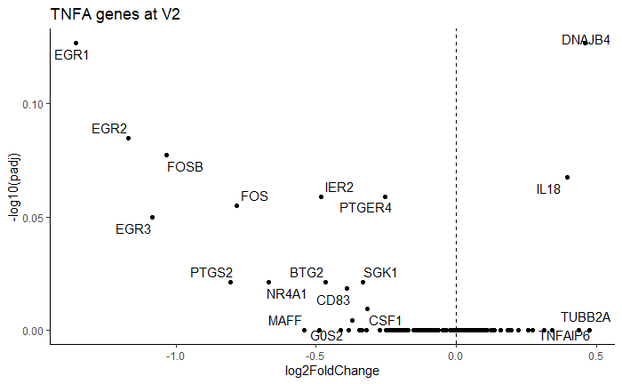

```r
rm(plot2); rm(ha_top); rm(zzz)

ggplot(subset(res.df, external_gene_name %in% msigDB[[fgseaRes[[2, 'pathway']]]]), aes(x = log2FoldChange, y = -log10(padj), label = external_gene_name)) + geom_point() + geom_text_repel() + theme_classic() + geom_vline(xintercept = 0, linetype = 2) + ggtitle('TNFA genes at V2')
```

Next, bone marrow gene sets from [Hay et al., 2018](https://www.ncbi.nlm.nih.gov/pmc/articles/PMC6296228/) were used to find cell type signatures differentially expressed between the two groups. Once again, erythroblast genes are very strongly and confidently “turned up”, likely an artifact of the increased proportion of eryhtroblasts.

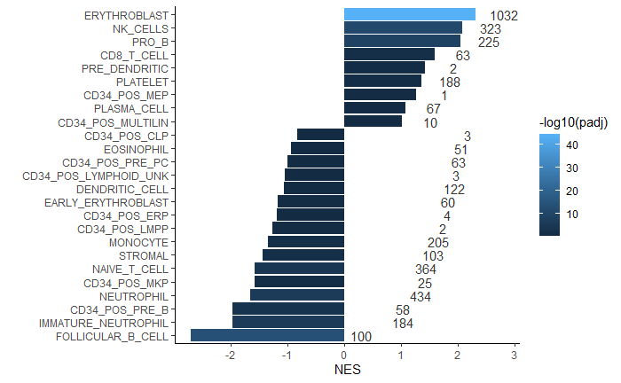

```r
msig.df = as.data.frame(msigdbr(species = "Homo sapiens", category = "C8")); msig.df = msig.df[grepl('HAY_BONE_MARROW', msig.df$gs_name), ]
msigDB = by(msig.df$gene_symbol, msig.df$gs_name, function(x) as.character(x)); names(msigDB) = gsub('HAY_BONE_MARROW_', '', names(msigDB))
fgseaRes = fgsea(pathways = msigDB, stats = ranks, nproc = 1); fgseaRes = fgseaRes[order(fgseaRes$padj, decreasing = FALSE), ]
write.csv(subset(fgseaRes, select = -c(leadingEdge)), file = 'results/fgseaRes_C8_marrow_v2.csv', row.names = FALSE)

ggplot(fgseaRes[1:25, ], aes(y = reorder(pathway, NES), x = NES, fill = -log10(padj), label = size)) +
  geom_col() + geom_text(color = 'gray20', nudge_x = ifelse(fgseaRes$NES > 0, 0.5, 3)) +
  ylab('') + theme_classic()
```

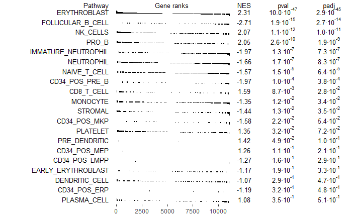

```r
plotGseaTable(msigDB[fgseaRes[1:20, ][, pathway]], ranks, fgseaRes[1:20, ], gseaParam = 0.5, colwidths = c(3, 3, 0.8, 1.2, 1.2), pathwayLabelStyle = list(size = 10), headerLabelStyle = list(size = 10), valueStyle = list(size = 10))
```

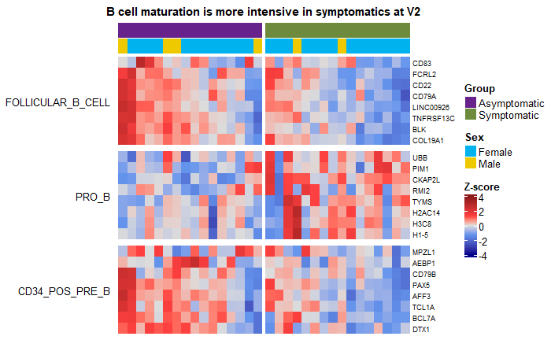

```r
res.df = res.df[order(res.df$log2FoldChange, decreasing = FALSE), ]
ha_top = HeatmapAnnotation(df = meta_data[, c('Group', 'Sex')], col = list(Group = c('Symptomatic' = 'darkolivegreen4', 'Asymptomatic' = 'darkorchid4'), Sex = c('Male' = 'gold2', 'Female' = 'deepskyblue2')), show_annotation_name = FALSE)
plot1 = vsd.df[rownames(subset(res.df, external_gene_name %in% msigDB[[fgseaRes[[2, 'pathway']]]] & log2FoldChange < 0))[1:8], ]
zzz = t(scale(t(plot1))); zzz = pmin(pmax(zzz, -3), 3); rownames(zzz) =  res.df[rownames(zzz), 'external_gene_name']
plot1 = Heatmap(zzz, row_title = fgseaRes[[2, 'pathway']], show_row_names = TRUE, show_column_names = FALSE, cluster_rows = TRUE, cluster_columns = TRUE, show_row_dend = FALSE, show_column_dend = FALSE, column_split = meta_data$Group, top_annotation = ha_top, heatmap_legend_param = list(title = "Z-score"), col = colorRamp2(c(-4, -1.25, 0, 1.25, 4), c("darkblue", "cornflowerblue", "gainsboro", "brown1", "firebrick4")), row_names_gp = gpar(fontsize = 7), row_title_rot = 0, row_title_gp = gpar(fontsize = 10), column_title_gp = gpar(fontsize = 11, fontface = 2), column_title = 'B cell maturation is more intensive in symptomatics at V2')
res.df = res.df[order(res.df$log2FoldChange, decreasing = TRUE), ]
plot2 = vsd.df[rownames(subset(res.df, external_gene_name %in% msigDB[[fgseaRes[[4, 'pathway']]]] & log2FoldChange > 0))[1:8], ]
zzz = t(scale(t(plot2))); zzz = pmin(pmax(zzz, -3), 3); rownames(zzz) =  res.df[rownames(zzz), 'external_gene_name']
plot2 = Heatmap(zzz, show_heatmap_legend = FALSE, row_title = fgseaRes[[4, 'pathway']], show_row_names = TRUE, show_column_names = FALSE, cluster_rows = TRUE, cluster_columns = TRUE, show_row_dend = FALSE, show_column_dend = FALSE, column_split = meta_data$Group, heatmap_legend_param = list(title = "Z-score"), col = colorRamp2(c(-4, -1.25, 0, 1.25, 4), c("darkblue", "cornflowerblue", "gainsboro", "brown1", "firebrick4")), row_names_gp = gpar(fontsize = 7), row_title_rot = 0, row_title_gp = gpar(fontsize = 10), column_title_gp = gpar(fontsize = 11, fontface = 2))
res.df = res.df[order(res.df$log2FoldChange, decreasing = FALSE), ]
plot3 = vsd.df[rownames(subset(res.df, external_gene_name %in% msigDB[[fgseaRes[[8, 'pathway']]]] & log2FoldChange < 0))[1:8], ]
zzz = t(scale(t(plot3))); zzz = pmin(pmax(zzz, -3), 3); rownames(zzz) =  res.df[rownames(zzz), 'external_gene_name']
plot3 = Heatmap(zzz, show_heatmap_legend = FALSE, row_title = fgseaRes[[8, 'pathway']], show_row_names = TRUE, show_column_names = FALSE, cluster_rows = TRUE, cluster_columns = TRUE, show_row_dend = FALSE, show_column_dend = FALSE, column_split = meta_data$Group, heatmap_legend_param = list(title = "Z-score"), col = colorRamp2(c(-4, -1.25, 0, 1.25, 4), c("darkblue", "cornflowerblue", "gainsboro", "brown1", "firebrick4")), row_names_gp = gpar(fontsize = 7), row_title_rot = 0, row_title_gp = gpar(fontsize = 10), column_title_gp = gpar(fontsize = 11, fontface = 2))
draw(plot1 %v% plot2 %v% plot3); rm(plot1); rm(plot2); rm(plot3); rm(zzz); rm(ha_top)
```

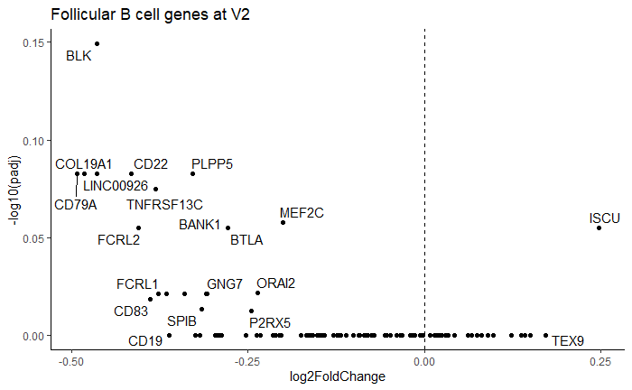

```r
ggplot(subset(res.df, external_gene_name %in% msigDB[[fgseaRes[[2, 'pathway']]]]), aes(x = log2FoldChange, y = -log10(padj), label = external_gene_name)) + geom_point() + geom_text_repel() + theme_classic() + geom_vline(xintercept = 0, linetype = 2) + ggtitle('Follicular B cell genes at V2')
```

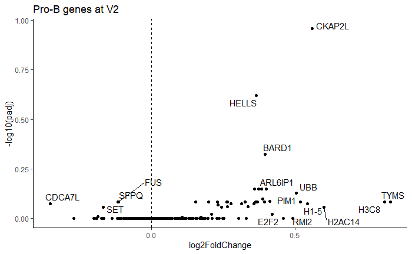

```r
ggplot(subset(res.df, external_gene_name %in% msigDB[[fgseaRes[[4, 'pathway']]]]), aes(x = log2FoldChange, y = -log10(padj), label = external_gene_name)) + geom_point() + geom_text_repel() + theme_classic() + geom_vline(xintercept = 0, linetype = 2) + ggtitle('Pro-B genes at V2')
```

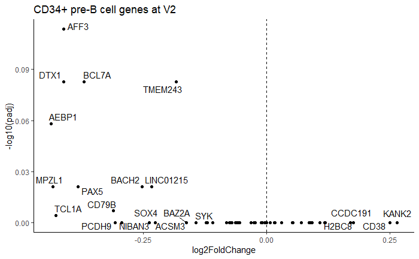

```r
ggplot(subset(res.df, external_gene_name %in% msigDB[[fgseaRes[[8, 'pathway']]]]), aes(x = log2FoldChange, y = -log10(padj), label = external_gene_name)) + geom_point() + geom_text_repel() + theme_classic() + geom_vline(xintercept = 0, linetype = 2) + ggtitle('CD34+ pre-B cell genes at V2')
```

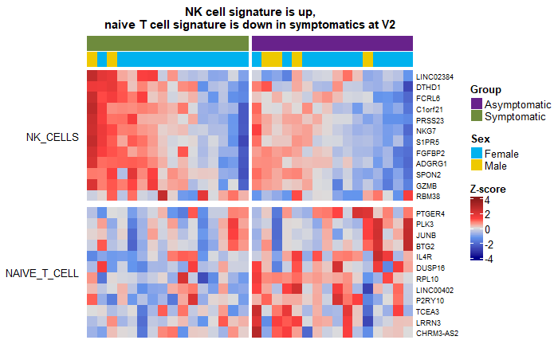

```r
res.df = res.df[order(res.df$log2FoldChange, decreasing = TRUE), ]
ha_top = HeatmapAnnotation(df = meta_data[, c('Group', 'Sex')], col = list(Group = c('Symptomatic' = 'darkolivegreen4', 'Asymptomatic' = 'darkorchid4'), Sex = c('Male' = 'gold2', 'Female' = 'deepskyblue2')), show_annotation_name = FALSE)
plot1 = vsd.df[rownames(subset(res.df, external_gene_name %in% msigDB[[fgseaRes[[3, 'pathway']]]] & log2FoldChange > 0))[1:12], ]
zzz = t(scale(t(plot1))); zzz = pmin(pmax(zzz, -3), 3); rownames(zzz) =  res.df[rownames(zzz), 'external_gene_name']
plot1 = Heatmap(zzz, row_title = fgseaRes[[3, 'pathway']], show_row_names = TRUE, show_column_names = FALSE, cluster_rows = TRUE, cluster_columns = TRUE, show_row_dend = FALSE, show_column_dend = FALSE, column_split = meta_data$Group, top_annotation = ha_top, heatmap_legend_param = list(title = "Z-score"), col = colorRamp2(c(-4, -1.25, 0, 1.25, 4), c("darkblue", "cornflowerblue", "gainsboro", "brown1", "firebrick4")), row_names_gp = gpar(fontsize = 7), row_title_rot = 0, row_title_gp = gpar(fontsize = 10), column_title_gp = gpar(fontsize = 11, fontface = 2), column_title = 'NK cell signature is up,\nnaive T cell signature is down in symptomatics at V2')
res.df = res.df[order(res.df$log2FoldChange, decreasing = FALSE), ]
plot2 = vsd.df[rownames(subset(res.df, external_gene_name %in% msigDB[[fgseaRes[[7, 'pathway']]]] & log2FoldChange < 0))[1:12], ]
zzz = t(scale(t(plot2))); zzz = pmin(pmax(zzz, -3), 3); rownames(zzz) =  res.df[rownames(zzz), 'external_gene_name']
plot2 = Heatmap(zzz, show_heatmap_legend = FALSE, row_title = fgseaRes[[7, 'pathway']], show_row_names = TRUE, show_column_names = FALSE, cluster_rows = TRUE, cluster_columns = TRUE, show_row_dend = FALSE, show_column_dend = FALSE, column_split = meta_data$Group, heatmap_legend_param = list(title = "Z-score"), col = colorRamp2(c(-4, -1.25, 0, 1.25, 4), c("darkblue", "cornflowerblue", "gainsboro", "brown1", "firebrick4")), row_names_gp = gpar(fontsize = 7), row_title_rot = 0, row_title_gp = gpar(fontsize = 10), column_title_gp = gpar(fontsize = 11, fontface = 2))
res.df = res.df[order(res.df$log2FoldChange, decreasing = FALSE), ]
draw(plot1 %v% plot2); rm(plot1); rm(plot2); rm(zzz); rm(ha_top)
```

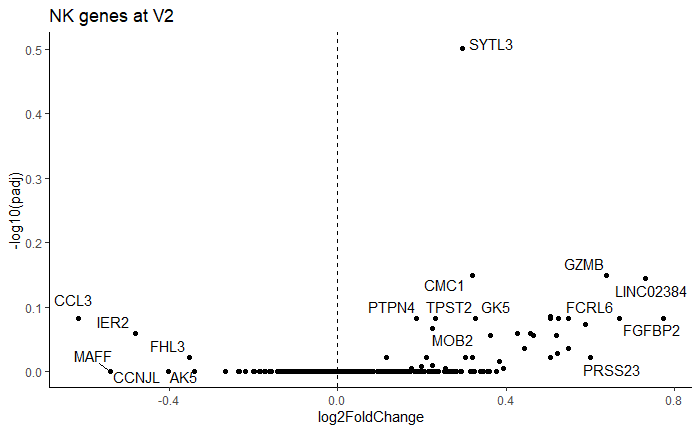

```r
ggplot(subset(res.df, external_gene_name %in% msigDB[[fgseaRes[[3, 'pathway']]]]), aes(x = log2FoldChange, y = -log10(padj), label = external_gene_name)) + geom_point() + geom_text_repel() + theme_classic() + ggtitle('NK genes at V2') + geom_vline(xintercept = 0, linetype = 2)
```

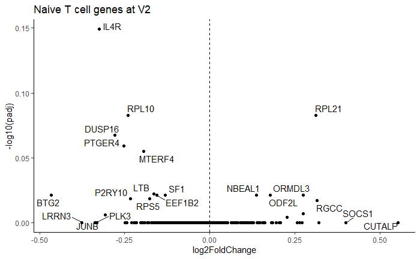

```r
ggplot(subset(res.df, external_gene_name %in% msigDB[[fgseaRes[[7, 'pathway']]]]), aes(x = log2FoldChange, y = -log10(padj), label = external_gene_name)) + geom_point() + geom_text_repel() + theme_classic() + ggtitle('Naive T cell genes at V2') + geom_vline(xintercept = 0, linetype = 2)
```

The neutrophil signatures observed above have to be treated separately. The volcano and enrichment plots below show that, unlike NK/B/T cell signatures above, the distribution of genes by padj and log2FoldChange does not convincingly agree with the NES value for these gene sets.

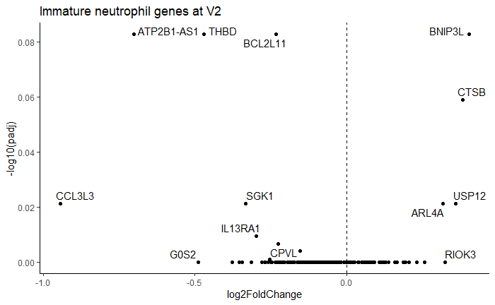

```r
ggplot(subset(res.df, external_gene_name %in% msigDB[[fgseaRes[[5, 'pathway']]]]), aes(x = log2FoldChange, y = -log10(padj), label = external_gene_name)) + geom_point() + geom_text_repel() + theme_classic() + ggtitle('Immature neutrophil genes at V2') + geom_vline(xintercept = 0, linetype = 2)
```

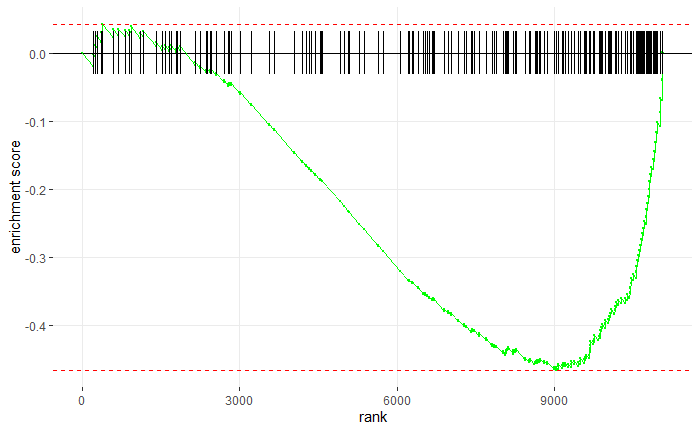

```r
plotEnrichment(msigDB[[fgseaRes[[5, 'pathway']]]], ranks, gseaParam = 1, ticksSize = 0.2)
```

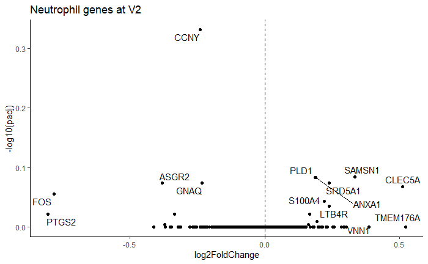

```r
ggplot(subset(res.df, external_gene_name %in% msigDB[[fgseaRes[[6, 'pathway']]]]), aes(x = log2FoldChange, y = -log10(padj), label = external_gene_name)) + geom_point() + geom_text_repel() + theme_classic() + ggtitle('Neutrophil genes at V2') + geom_vline(xintercept = 0, linetype = 2)
```

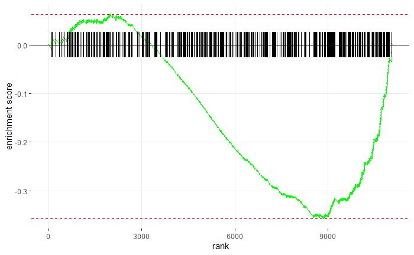

```r
plotEnrichment(msigDB[[fgseaRes[[6, 'pathway']]]], ranks, gseaParam = 1, ticksSize = 0.2)
```

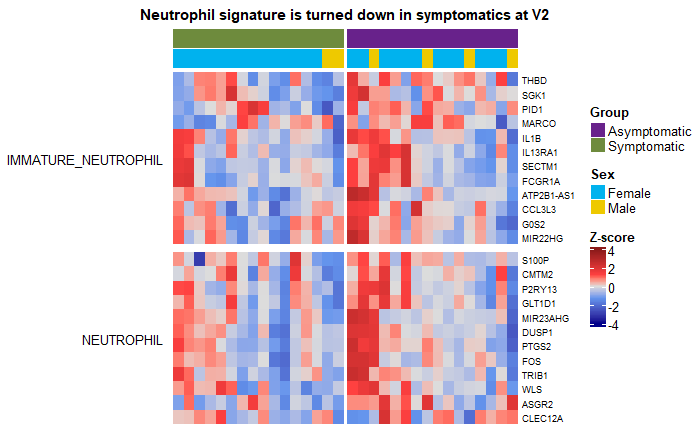

```r
res.df = res.df[order(res.df$log2FoldChange, decreasing = FALSE), ]
ha_top = HeatmapAnnotation(df = meta_data[, c('Group', 'Sex')], col = list(Group = c('Symptomatic' = 'darkolivegreen4', 'Asymptomatic' = 'darkorchid4'), Sex = c('Male' = 'gold2', 'Female' = 'deepskyblue2')), show_annotation_name = FALSE)
plot1 = vsd.df[rownames(subset(res.df, external_gene_name %in% msigDB[[fgseaRes[[5, 'pathway']]]] & log2FoldChange < 0))[1:12], ]
zzz = t(scale(t(plot1))); zzz = pmin(pmax(zzz, -3), 3); rownames(zzz) =  res.df[rownames(zzz), 'external_gene_name']
plot1 = Heatmap(zzz, row_title = fgseaRes[[5, 'pathway']], show_row_names = TRUE, show_column_names = FALSE, cluster_rows = TRUE, cluster_columns = TRUE, show_row_dend = FALSE, show_column_dend = FALSE, column_split = meta_data$Group, top_annotation = ha_top, heatmap_legend_param = list(title = "Z-score"), col = colorRamp2(c(-4, -1.25, 0, 1.25, 4), c("darkblue", "cornflowerblue", "gainsboro", "brown1", "firebrick4")), row_names_gp = gpar(fontsize = 7), row_title_rot = 0, row_title_gp = gpar(fontsize = 10), column_title_gp = gpar(fontsize = 11, fontface = 2), column_title = 'Neutrophil signature is turned down in symptomatics at V2')
plot2 = vsd.df[rownames(subset(res.df, external_gene_name %in% msigDB[[fgseaRes[[6, 'pathway']]]] & log2FoldChange < 0))[1:12], ]
zzz = t(scale(t(plot2))); zzz = pmin(pmax(zzz, -3), 3); rownames(zzz) =  res.df[rownames(zzz), 'external_gene_name']
plot2 = Heatmap(zzz, show_heatmap_legend = FALSE, row_title = fgseaRes[[6, 'pathway']], show_row_names = TRUE, show_column_names = FALSE, cluster_rows = TRUE, cluster_columns = TRUE, show_row_dend = FALSE, show_column_dend = FALSE, column_split = meta_data$Group, heatmap_legend_param = list(title = "Z-score"), col = colorRamp2(c(-4, -1.25, 0, 1.25, 4), c("darkblue", "cornflowerblue", "gainsboro", "brown1", "firebrick4")), row_names_gp = gpar(fontsize = 7), row_title_rot = 0, row_title_gp = gpar(fontsize = 10), column_title_gp = gpar(fontsize = 11, fontface = 2))

draw(plot1 %v% plot2); rm(plot1); rm(plot2); rm(zzz); rm(ha_top)
```

GSEA with BTMs mostly confirms these findings. B cell signature is down in the symptomatic group, agreeing with flow data, and NK cells are more active. The idea that T cells are also differentiating more intensively is supported here (enriched in T cells module). Finally, the reduced neutrophil signature is more solid with BTMs, but the reduced monocyte signature is dubious and only included for reference.

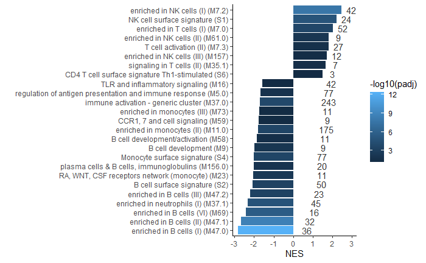

```r
btm = readRDS('data/Blood_Transcript_modules.RDS'); btm_annot = read_excel('data/btm_annotation_table.xls')
btm_annot = subset(btm_annot, `Module category` == 'immune'); btm = btm[c(btm_annot$ID)]; names(btm) = btm_annot$`Composite name`
fgseaRes = fgsea(pathways = btm, stats = ranks, nproc = 1); fgseaRes = fgseaRes[order(fgseaRes$padj, decreasing = FALSE), ]
write.csv(subset(fgseaRes, select = -c(leadingEdge)), file = 'results/fgseaRes_btm_immune_v2.csv', row.names = FALSE)

fgseaRes = fgseaRes[pathway %in% subset(btm_annot, `Module category` == 'immune')$`Composite name`, ]
ggplot(fgseaRes[1:25, ], aes(y = reorder(pathway, NES), x = NES, fill = -log10(padj), label = size)) + geom_col() + geom_text(color = 'gray20', nudge_x = ifelse(fgseaRes$NES > 0, 0.5, 3.5)) + ylab('') + theme_classic()
```

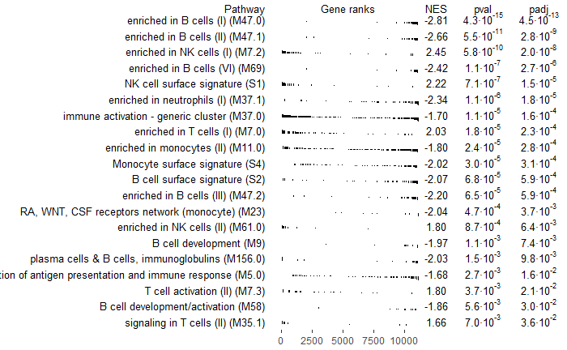

```r
plotGseaTable(btm[fgseaRes[1:20, ][, pathway]], ranks, fgseaRes[1:20, ], gseaParam = 0.5, colwidths = c(6, 3, 0.8, 1.2, 1.2), pathwayLabelStyle = list(size = 10), headerLabelStyle = list(size = 10), valueStyle = list(size = 10))
```

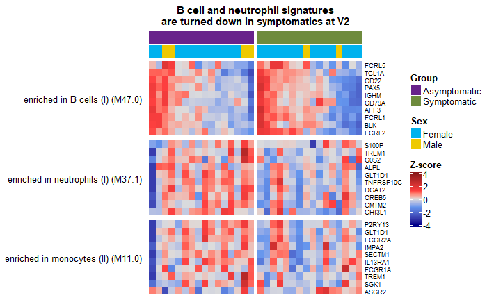

```r
res.df = res.df[order(res.df$log2FoldChange, decreasing = FALSE), ]
ha_top = HeatmapAnnotation(df = meta_data[, c('Group', 'Sex')], col = list(Group = c('Symptomatic' = 'darkolivegreen4', 'Asymptomatic' = 'darkorchid4'), Sex = c('Male' = 'gold2', 'Female' = 'deepskyblue2')), show_annotation_name = FALSE)
plot1 = vsd.df[rownames(subset(res.df, external_gene_name %in% btm[[fgseaRes[[1, 'pathway']]]] & log2FoldChange < 0))[1:10], ]
zzz = t(scale(t(plot1))); zzz = pmin(pmax(zzz, -3), 3); rownames(zzz) =  res.df[rownames(zzz), 'external_gene_name']
plot1 = Heatmap(zzz, row_title = fgseaRes[[1, 'pathway']], show_row_names = TRUE, show_column_names = FALSE, cluster_rows = TRUE, cluster_columns = TRUE, show_row_dend = FALSE, show_column_dend = FALSE, column_split = meta_data$Group, top_annotation = ha_top, heatmap_legend_param = list(title = "Z-score"), col = colorRamp2(c(-4, -1.25, 0, 1.25, 4), c("darkblue", "cornflowerblue", "gainsboro", "brown1", "firebrick4")), row_names_gp = gpar(fontsize = 7), row_title_rot = 0, row_title_gp = gpar(fontsize = 10), column_title_gp = gpar(fontsize = 11, fontface = 2), column_title = 'B cell and neutrophil signatures\nare turned down in symptomatics at V2')
plot2 = vsd.df[rownames(subset(res.df, external_gene_name %in% btm[[fgseaRes[[6, 'pathway']]]] & log2FoldChange < 0))[1:10], ]
zzz = t(scale(t(plot2))); zzz = pmin(pmax(zzz, -3), 3); rownames(zzz) =  res.df[rownames(zzz), 'external_gene_name']
plot2 = Heatmap(zzz, show_heatmap_legend = FALSE, row_title = fgseaRes[[6, 'pathway']], show_row_names = TRUE, show_column_names = FALSE, cluster_rows = TRUE, cluster_columns = TRUE, show_row_dend = FALSE, show_column_dend = FALSE, column_split = meta_data$Group, heatmap_legend_param = list(title = "Z-score"), col = colorRamp2(c(-4, -1.25, 0, 1.25, 4), c("darkblue", "cornflowerblue", "gainsboro", "brown1", "firebrick4")), row_names_gp = gpar(fontsize = 7), row_title_rot = 0, row_title_gp = gpar(fontsize = 10), column_title_gp = gpar(fontsize = 11, fontface = 2))
plot3 = vsd.df[rownames(subset(res.df, external_gene_name %in% btm[[fgseaRes[[9, 'pathway']]]] & log2FoldChange < 0))[1:10], ]
zzz = t(scale(t(plot3))); zzz = pmin(pmax(zzz, -3), 3); rownames(zzz) =  res.df[rownames(zzz), 'external_gene_name']
plot3 = Heatmap(zzz, show_heatmap_legend = FALSE, row_title = fgseaRes[[9, 'pathway']], show_row_names = TRUE, show_column_names = FALSE, cluster_rows = TRUE, cluster_columns = TRUE, show_row_dend = FALSE, show_column_dend = FALSE, column_split = meta_data$Group, heatmap_legend_param = list(title = "Z-score"), col = colorRamp2(c(-4, -1.25, 0, 1.25, 4), c("darkblue", "cornflowerblue", "gainsboro", "brown1", "firebrick4")), row_names_gp = gpar(fontsize = 7), row_title_rot = 0, row_title_gp = gpar(fontsize = 10), column_title_gp = gpar(fontsize = 11, fontface = 2))
draw(plot1 %v% plot2 %v% plot3)
```

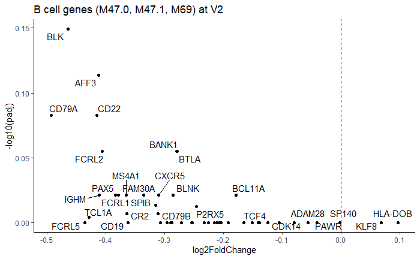

```r
ggplot(subset(res.df, external_gene_name %in% btm[[fgseaRes[[1, 'pathway']]]] | external_gene_name %in% btm[[fgseaRes[[2, 'pathway']]]] | external_gene_name %in% btm[[fgseaRes[[4, 'pathway']]]]), aes(x = log2FoldChange, y = -log10(padj), label = external_gene_name)) + geom_point() + geom_text_repel() + theme_classic() + ggtitle('B cell genes (M47.0, M47.1, M69) at V2') + geom_vline(xintercept = 0, linetype = 2)
```

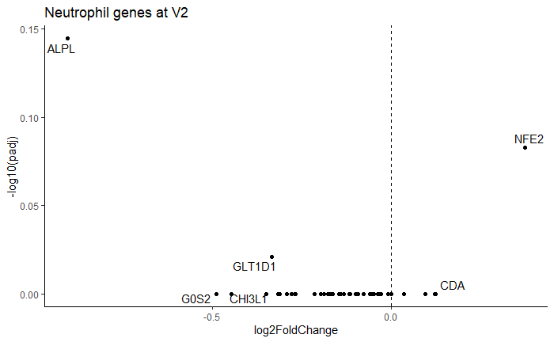

```r
ggplot(subset(res.df, external_gene_name %in% btm[[fgseaRes[[6, 'pathway']]]]), aes(x = log2FoldChange, y = -log10(padj), label = external_gene_name)) + geom_point() + geom_text_repel() + theme_classic() + ggtitle('Neutrophil genes at V2') + geom_vline(xintercept = 0, linetype = 2)
```

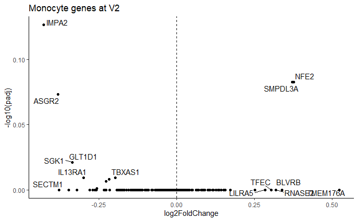

```r
ggplot(subset(res.df, external_gene_name %in% btm[[fgseaRes[[9, 'pathway']]]]), aes(x = log2FoldChange, y = -log10(padj), label = external_gene_name)) + geom_point() + geom_text_repel() + theme_classic() + ggtitle('Monocyte genes at V2') + geom_vline(xintercept = 0, linetype = 2)
```

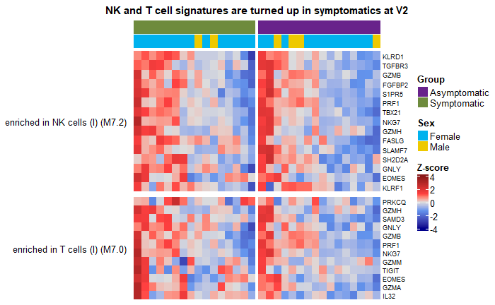

```r
res.df = res.df[order(res.df$log2FoldChange, decreasing = TRUE), ]
plot4 = vsd.df[rownames(subset(res.df, external_gene_name %in% btm[[fgseaRes[[3, 'pathway']]]] & log2FoldChange > 0))[1:15], ]
zzz = t(scale(t(plot4))); zzz = pmin(pmax(zzz, -3), 3); rownames(zzz) =  res.df[rownames(zzz), 'external_gene_name']
plot4 = Heatmap(zzz, row_title = fgseaRes[[3, 'pathway']], show_row_names = TRUE, show_column_names = FALSE, cluster_rows = TRUE, cluster_columns = TRUE, show_row_dend = FALSE, show_column_dend = FALSE, column_split = meta_data$Group, top_annotation = ha_top, heatmap_legend_param = list(title = "Z-score"), col = colorRamp2(c(-4, -1.25, 0, 1.25, 4), c("darkblue", "cornflowerblue", "gainsboro", "brown1", "firebrick4")), row_names_gp = gpar(fontsize = 7), row_title_rot = 0, row_title_gp = gpar(fontsize = 10), column_title_gp = gpar(fontsize = 11, fontface = 2), heatmap_height = unit(7, 'cm'), column_title = 'NK and T cell signatures are turned up in symptomatics at V2')
plot5 = vsd.df[rownames(subset(res.df, external_gene_name %in% btm[[fgseaRes[[8, 'pathway']]]] & log2FoldChange > 0))[1:12], ]
zzz = t(scale(t(plot5))); zzz = pmin(pmax(zzz, -3), 3); rownames(zzz) =  res.df[rownames(zzz), 'external_gene_name']
plot5 = Heatmap(zzz, row_title = fgseaRes[[8, 'pathway']], show_row_names = TRUE, show_column_names = FALSE, cluster_rows = TRUE, cluster_columns = TRUE, show_row_dend = FALSE, show_column_dend = TRUE, column_split = meta_data$Group, heatmap_legend_param = list(title = "Z-score"), col = colorRamp2(c(-4, -1.25, 0, 1.25, 4), c("darkblue", "cornflowerblue", "gainsboro", "brown1", "firebrick4")), row_names_gp = gpar(fontsize = 7), row_title_rot = 0, row_title_gp = gpar(fontsize = 10), column_title_gp = gpar(fontsize = 11, fontface = 2), show_heatmap_legend = FALSE)
draw(plot4 %v% plot5)
```

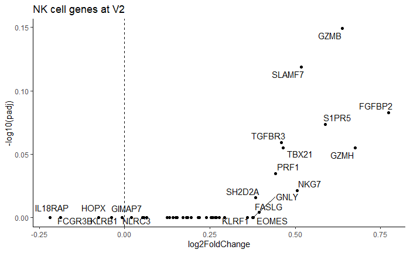

```r
ggplot(subset(res.df, external_gene_name %in% btm[[fgseaRes[[3, 'pathway']]]]), aes(x = log2FoldChange, y = -log10(padj), label = external_gene_name)) + geom_point() + geom_text_repel() + theme_classic() + ggtitle('NK cell genes at V2') + geom_vline(xintercept = 0, linetype = 2)
```

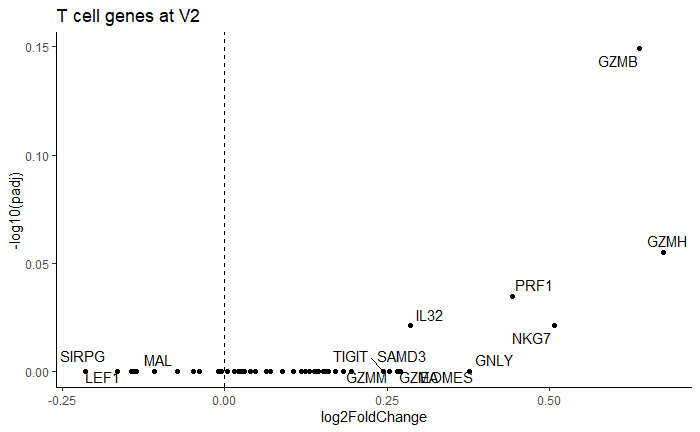

```r
ggplot(subset(res.df, external_gene_name %in% btm[[fgseaRes[[8, 'pathway']]]]), aes(x = log2FoldChange, y = -log10(padj), label = external_gene_name)) + geom_point() + geom_text_repel() + theme_classic() + ggtitle('T cell genes at V2') + geom_vline(xintercept = 0, linetype = 2)
```

```r
rm(plot1); rm(plot2); rm(plot3); rm(plot4); rm(plot5); rm(zzz); rm(ha_top)
```

### 5. V0 GSEA

```r
keep = data.frame(cbind(Participant.ID = meta_data$Participant.ID, Group = meta_data$Group))
```

```r
count_data = readRDS('data/Raw_RNASeq_Data.RDS')
ens2gene = readRDS("data/ens2gene.RDS")
meta_data = data.frame(read.csv('data/COVIRS_metadata.csv', header = TRUE))
meta_data = meta_data[meta_data$Timepoint == 'V0' & meta_data$First.Second.vaccine == 'BNT162b2', ]
meta_data = meta_data[meta_data$Participant.ID %in% keep$Participant.ID, ]; meta_data$Group = keep$Group

ensgene = rownames(count_data); count_data = count_data[, colnames(count_data) %in% meta_data$id]; count_data = data.frame(cbind(ensgene = ensgene, count_data)); rownames(count_data) = NULL; rm(ensgene); rm(keep)
```

```r
dds = DESeqDataSetFromMatrix(countData = count_data,
                              colData = meta_data,
                              design= ~ Group + Sex, tidy = TRUE)
vsd = vst(dds, blind = FALSE); vsd.df = assay(vsd); write.csv(vsd.df, file = 'results/counts_norm_v0.csv', row.names = TRUE)
```

```r
keep = rowSums(counts(dds) > 100) >= 4; dds = dds[keep, ]; dds = DESeq(dds)
```

```
-- replacing outliers and refitting for 19 genes
-- DESeq argument 'minReplicatesForReplace' = 7
-- original counts are preserved in counts(dds)
```

```r
res = results(dds, contrast = c("Group", "Symptomatic", "Asymptomatic")); res = res[order(res$padj, decreasing = FALSE), ]
res; summary(res); res.df = data.frame(res); res.df = data.frame(res.df, ens2gene[rownames(res.df), ]); write.csv(res.df, file = 'results/res_deseq_v0.csv', row.names = TRUE)
```

```
log2 fold change (MLE): Group Symptomatic vs Asymptomatic
Wald test p-value: Group Symptomatic vs Asymptomatic
DataFrame with 11229 rows and 6 columns
                 baseMean log2FoldChange     lfcSE       stat      pvalue        padj
                <numeric>      <numeric> <numeric>  <numeric>   <numeric>   <numeric>
ENSG00000207389   905.246      -5.386487 0.7176174   -7.50607 6.09286e-14 6.83863e-10
ENSG00000170915   313.277       0.422574 0.0942592    4.48310 7.35649e-06 4.12846e-02
ENSG00000169508   642.807       0.421562 0.0966748    4.36061 1.29698e-05 4.24441e-02
ENSG00000108384   204.533       0.363181 0.0839366    4.32684 1.51262e-05 4.24441e-02
ENSG00000130202   125.110      -2.122512 0.5016004   -4.23148 2.32157e-05 5.21147e-02
...                   ...            ...       ...        ...         ...         ...
ENSG00000123838   41.6755     -3.2523776  0.624424 -5.2086061          NA          NA
ENSG00000239899  251.3011      1.1974009  0.575360  2.0811347          NA          NA
ENSG00000233913  206.2764     -0.0132661  0.346732 -0.0382605          NA          NA
ENSG00000254612   75.9356     -0.1343210  0.199588 -0.6729914          NA          NA
ENSG00000078114   23.3453     -0.7735165  0.495343 -1.5615775          NA          NA

out of 11229 with nonzero total read count
adjusted p-value < 0.1
LFC > 0 (up)       : 5, 0.045%
LFC < 0 (down)     : 2, 0.018%
outliers [1]       : 5, 0.045%
low counts [2]     : 0, 0%
(mean count < 20)
[1] see 'cooksCutoff' argument of ?results
[2] see 'independentFiltering' argument of ?results
```

```r
rm(keep)
```

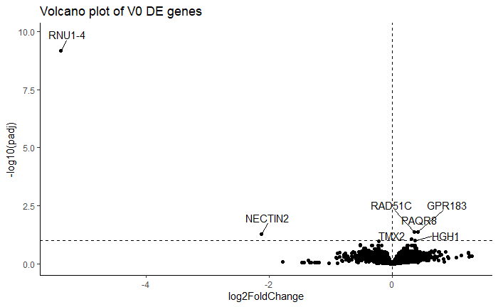

```r
ggplot(res.df, aes(x = log2FoldChange, y = -log10(padj))) + geom_point() +
  geom_hline(yintercept = -log10(0.1), linetype = 2) + geom_vline(xintercept = 0, linetype = 2) +
  theme_classic() + geom_text_repel(data = subset(res.df, -log10(padj) > 1), aes(x = log2FoldChange, y = -log10(padj), label = external_gene_name), max.overlaps = 9, position = position_nudge_repel(x = 0.1, y = 0.7)) + ggtitle("Volcano plot of V0 DE genes")
```

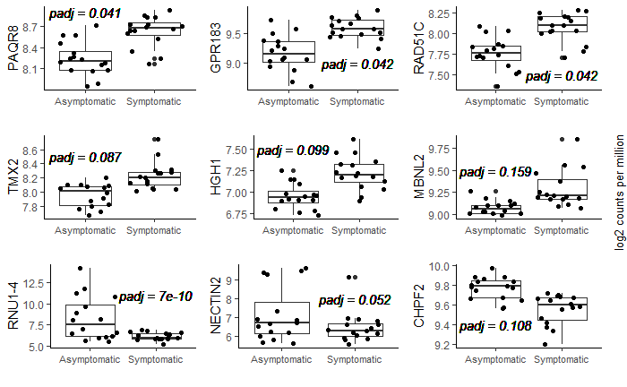

```r
plot = rbind(filter(res.df, log2FoldChange > 0)[1:6, ], filter(res.df, log2FoldChange < 0)[1:3, ])
vsd.df = data.frame(t(vsd.df)); vsd.df$Group = meta_data$Group; vsd.df$Sex = meta_data$Sex

plot1 = ggplot(vsd.df, aes(x = Group, y = vsd.df[, rownames(plot)[1]])) + geom_boxplot() + geom_jitter() + ylab(res.df[rownames(plot)[1], 'external_gene_name']) + geom_text(aes(x = 1, y = 8.9, fontface = 3), label = paste0('padj = ', as.character(round(res.df[rownames(plot)[1], 'padj'], 3)))) + theme_classic() + xlab('') + theme(axis.text.x = element_text(size = 8))
plot2 = ggplot(vsd.df, aes(x = Group, y = vsd.df[, rownames(plot)[2]])) + geom_boxplot() + geom_jitter() + ylab(res.df[rownames(plot)[2], 'external_gene_name']) + geom_text(aes(x = 2, y = 9.0, fontface = 3), label = paste0('padj = ', as.character(round(res.df[rownames(plot)[2], 'padj'], 3)))) + theme_classic() + xlab('') + theme(axis.text.x = element_text(size = 8))
plot3 = ggplot(vsd.df, aes(x = Group, y = vsd.df[, rownames(plot)[3]])) + geom_boxplot() + geom_jitter() + ylab(res.df[rownames(plot)[3], 'external_gene_name']) + geom_text(aes(x = 2, y = 7.5, fontface = 3), label = paste0('padj = ', as.character(round(res.df[rownames(plot)[3], 'padj'], 3)))) + theme_classic() + xlab('') + theme(axis.text.x = element_text(size = 8))
plot4 = ggplot(vsd.df, aes(x = Group, y = vsd.df[, rownames(plot)[4]])) + geom_boxplot() + geom_jitter() + ylab(res.df[rownames(plot)[4], 'external_gene_name']) + geom_text(aes(x = 1, y = 8.5, fontface = 3), label = paste0('padj = ', as.character(round(res.df[rownames(plot)[4], 'padj'], 3)))) + theme_classic() + xlab('') + theme(axis.text.x = element_text(size = 8))
plot5 = ggplot(vsd.df, aes(x = Group, y = vsd.df[, rownames(plot)[5]])) + geom_boxplot() + geom_jitter() + ylab(res.df[rownames(plot)[5], 'external_gene_name']) + geom_text(aes(x = 1, y = 7.5, fontface = 3), label = paste0('padj = ', as.character(round(res.df[rownames(plot)[5], 'padj'], 3)))) + theme_classic() + xlab('') + theme(axis.text.x = element_text(size = 8))
plot6 = ggplot(vsd.df, aes(x = Group, y = vsd.df[, rownames(plot)[6]])) + geom_boxplot() + geom_jitter() + ylab(res.df[rownames(plot)[6], 'external_gene_name']) + geom_text(aes(x = 1, y = 9.5, fontface = 3), label = paste0('padj = ', as.character(round(res.df[rownames(plot)[6], 'padj'], 3)))) + theme_classic() + xlab('') + theme(axis.text.x = element_text(size = 8))
plot7 = ggplot(vsd.df, aes(x = Group, y = vsd.df[, rownames(plot)[7]])) + geom_boxplot() + geom_jitter() + ylab(res.df[rownames(plot)[7], 'external_gene_name']) + geom_text(aes(x = 2, y = 11, fontface = 3), label = paste0('padj = ', as.character(round(res.df[rownames(plot)[7], 'padj'], 10)))) + theme_classic() + xlab('') + theme(axis.text.x = element_text(size = 8))
plot8 = ggplot(vsd.df, aes(x = Group, y = vsd.df[, rownames(plot)[8]])) + geom_boxplot() + geom_jitter() + ylab(res.df[rownames(plot)[8], 'external_gene_name']) + geom_text(aes(x = 2, y = 8, fontface = 3), label = paste0('padj = ', as.character(round(res.df[rownames(plot)[8], 'padj'], 3)))) + theme_classic() + xlab('') + theme(axis.text.x = element_text(size = 8))
plot9 = ggplot(vsd.df, aes(x = Group, y = vsd.df[, rownames(plot)[9]])) + geom_boxplot() + geom_jitter() + ylab(res.df[rownames(plot)[9], 'external_gene_name']) + geom_text(aes(x = 1, y = 9.4, fontface = 3), label = paste0('padj = ', as.character(round(res.df[rownames(plot)[9], 'padj'], 3)))) + theme_classic() + xlab('') + theme(axis.text.x = element_text(size = 8))
grid.arrange(plot1, plot2, plot3, plot4, plot5, plot6, plot7, plot8, plot9, ncol = 3, right = textGrob('log2 counts per million', rot = 90, gp = gpar(fontsize = 10)))
```

```r
vsd.df$Sex = NULL; vsd.df$Group = NULL; vsd.df = data.frame(t(vsd.df))
rm(plot); rm(plot1); rm(plot2); rm(plot3); rm(plot4); rm(plot5); rm(plot6)
```

PAQR8: [Groh et al. (2022)](https://doi.org/10.1002/jlb.3ab1220-846r) find that progesterone receptor activates monocyte immunity trained by LDLs

GPR183: required for immune cell maturation through oxysterol chemotaxis in lymph nodes [(Daugvilaite et al., 2014)](https://doi.org/10.1002/eji.201444493)

RAD51C: linked to poor ovarian cancer prognosis, no clear link with immune system [(Lu et al., 2020)](https://www.ncbi.nlm.nih.gov/pmc/articles/PMC7013370/)

NECTIN2: bound by inhibitory T cell receptor [(Deuss et al., 2017)](https://doi.org/10.1074/jbc.m117.786483)

RNU1-4: no clear function or useful references from [GeneCards](https://www.genecards.org/cgi-bin/carddisp.pl?gene=RNU1-4)

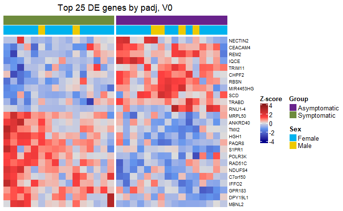

```r
ha_top = HeatmapAnnotation(df = meta_data[, c('Group', 'Sex')], col = list(Group = c('Symptomatic' = 'darkolivegreen4', 'Asymptomatic' = 'darkorchid4'), Sex = c('Male' = 'gold2', 'Female' = 'deepskyblue2')), show_annotation_name = FALSE)
zzz = t(scale(t(vsd.df[rownames(res.df[1:25, ]), ]))); zzz = pmin(pmax(zzz, -3), 3); rownames(zzz) =  res.df[rownames(zzz), 'external_gene_name']
Heatmap(zzz, show_row_names = TRUE, show_column_names = FALSE, cluster_rows = TRUE, cluster_columns = TRUE, show_row_dend = FALSE, show_column_dend = FALSE, top_annotation = ha_top, heatmap_legend_param = list(title = "Z-score"), col = colorRamp2(c(-4, -1.25, 0, 1.25, 4), c("darkblue", "cornflowerblue", "gainsboro", "brown1", "firebrick4")), row_names_gp = gpar(fontsize = 7), column_title = 'Top 25 DE genes by padj, V0', column_split = meta_data$Group)
```

```r
rm(ha_top); rm(zzz)
```

```r
ranks <- res.df %>%
  as_tibble() %>%
  dplyr::select(external_gene_name, log2FoldChange) %>%
  na.omit() %>%
  distinct() %>%
  group_by(external_gene_name) %>%
  summarize(log2FoldChange=mean(log2FoldChange))
ranks <- deframe(ranks)
```

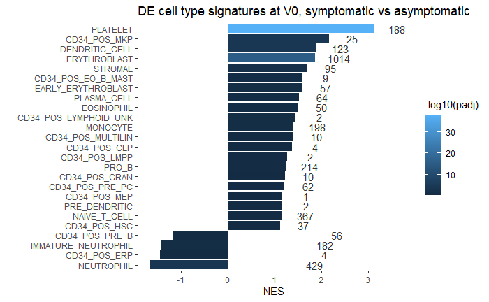

```r
msig.df = as.data.frame(msigdbr(species = "Homo sapiens", category = "C8")); msig.df = msig.df[grepl('HAY_BONE_MARROW', msig.df$gs_name), ]
msigDB = by(msig.df$gene_symbol, msig.df$gs_name, function(x) as.character(x)); names(msigDB) = gsub('HAY_BONE_MARROW_', '', names(msigDB))
fgseaRes = fgsea(pathways = msigDB, stats = ranks, nproc = 1); fgseaRes = fgseaRes[order(fgseaRes$padj, decreasing = FALSE), ]
write.csv(subset(fgseaRes, select = -c(leadingEdge)), file = 'results/fgseaRes_C8_marrow_v0.csv', row.names = FALSE)

ggplot(fgseaRes[1:25, ], aes(y = reorder(pathway, NES), x = NES, fill = -log10(padj), label = size)) +
  geom_col() + geom_text(color = 'gray20', nudge_x = ifelse(fgseaRes$NES > 0, 0.5, 3.5)) +
  ylab('') + theme_classic() + ggtitle('DE cell type signatures at V0, symptomatic vs asymptomatic')
```

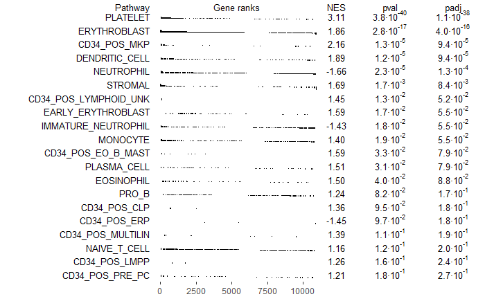

```r
plotGseaTable(msigDB[fgseaRes[1:20, ][, pathway]], ranks, fgseaRes[1:20, ], gseaParam = 0.5, colwidths = c(3, 3, 0.8, 1.2, 1.2), pathwayLabelStyle = list(size = 10), headerLabelStyle = list(size = 10), valueStyle = list(size = 10))
```

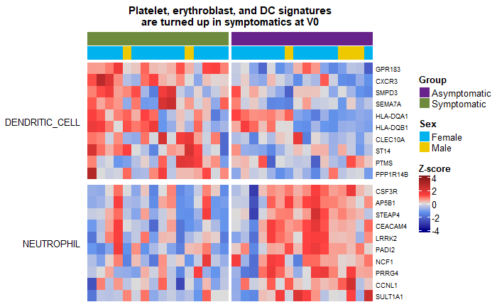

```r
res.df = res.df[order(res.df$log2FoldChange, decreasing = TRUE), ]
ha_top = HeatmapAnnotation(df = meta_data[, c('Group', 'Sex')], col = list(Group = c('Symptomatic' = 'darkolivegreen4', 'Asymptomatic' = 'darkorchid4'), Sex = c('Male' = 'gold2', 'Female' = 'deepskyblue2')), show_annotation_name = FALSE)
plot1 = vsd.df[rownames(subset(res.df, external_gene_name %in% msigDB[[fgseaRes[[4, 'pathway']]]] & log2FoldChange > 0))[1:10], ]
zzz = t(scale(t(plot1))); zzz = pmin(pmax(zzz, -3), 3); rownames(zzz) =  res.df[rownames(zzz), 'external_gene_name']
plot1 = Heatmap(zzz, row_title = fgseaRes[[4, 'pathway']], show_row_names = TRUE, show_column_names = FALSE, cluster_rows = TRUE, cluster_columns = TRUE, show_row_dend = FALSE, show_column_dend = FALSE, column_split = meta_data$Group, top_annotation = ha_top, heatmap_legend_param = list(title = "Z-score"), col = colorRamp2(c(-4, -1.25, 0, 1.25, 4), c("darkblue", "cornflowerblue", "gainsboro", "brown1", "firebrick4")), row_names_gp = gpar(fontsize = 7), row_title_rot = 0, row_title_gp = gpar(fontsize = 10), column_title_gp = gpar(fontsize = 11, fontface = 2), column_title = 'Platelet, erythroblast, and DC signatures\nare turned up in symptomatics at V0')
res.df = res.df[order(res.df$log2FoldChange, decreasing = FALSE), ]
plot2 = vsd.df[rownames(subset(res.df, external_gene_name %in% msigDB[[fgseaRes[[5, 'pathway']]]] & log2FoldChange < 0))[1:10], ]
zzz = t(scale(t(plot2))); zzz = pmin(pmax(zzz, -3), 3); rownames(zzz) =  res.df[rownames(zzz), 'external_gene_name']
plot2 = Heatmap(zzz, show_heatmap_legend = FALSE, row_title = fgseaRes[[5, 'pathway']], show_row_names = TRUE, show_column_names = FALSE, cluster_rows = TRUE, cluster_columns = TRUE, show_row_dend = FALSE, show_column_dend = FALSE, column_split = meta_data$Group, heatmap_legend_param = list(title = "Z-score"), col = colorRamp2(c(-4, -1.25, 0, 1.25, 4), c("darkblue", "cornflowerblue", "gainsboro", "brown1", "firebrick4")), row_names_gp = gpar(fontsize = 7), row_title_rot = 0, row_title_gp = gpar(fontsize = 10), column_title_gp = gpar(fontsize = 11, fontface = 2))
draw(plot1 %v% plot2); rm(plot1); rm(plot2); rm(zzz); rm(ha_top)
```

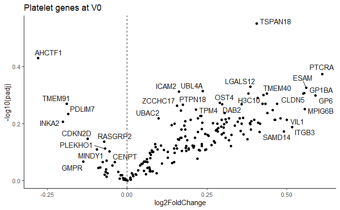

```r
ggplot(subset(res.df, external_gene_name %in% msigDB[[fgseaRes[[1, 'pathway']]]]), aes(x = log2FoldChange, y = -log10(padj), label = external_gene_name)) + geom_point() + geom_text_repel() + theme_classic() + ggtitle('Platelet genes at V0') + geom_vline(xintercept = 0, linetype = 2)
```

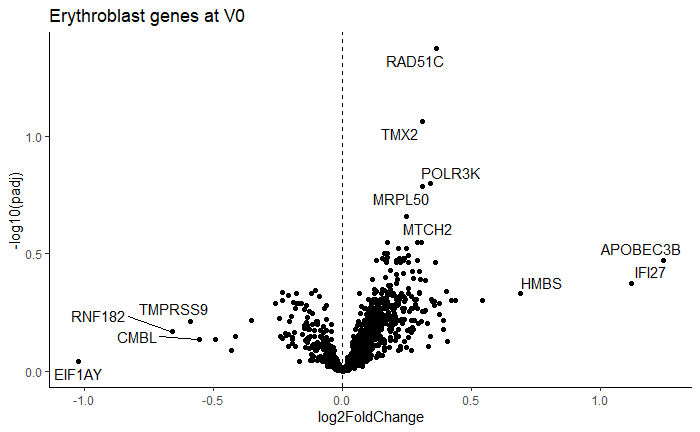

```r
ggplot(subset(res.df, external_gene_name %in% msigDB[[fgseaRes[[2, 'pathway']]]]), aes(x = log2FoldChange, y = -log10(padj), label = external_gene_name)) + geom_point() + geom_text_repel() + theme_classic() + ggtitle('Erythroblast genes at V0') + geom_vline(xintercept = 0, linetype = 2)
```

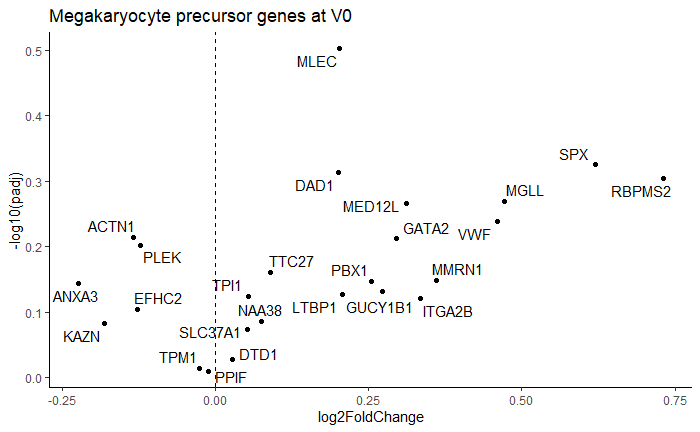

```r
ggplot(subset(res.df, external_gene_name %in% msigDB[[fgseaRes[[3, 'pathway']]]]), aes(x = log2FoldChange, y = -log10(padj), label = external_gene_name)) + geom_point() + geom_text_repel() + theme_classic() + ggtitle('Megakaryocyte precursor genes at V0') + geom_vline(xintercept = 0, linetype = 2)
```

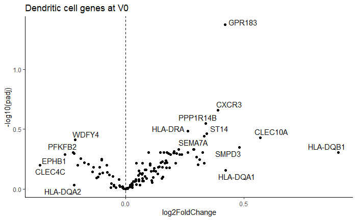

```r
ggplot(subset(res.df, external_gene_name %in% msigDB[[fgseaRes[[4, 'pathway']]]]), aes(x = log2FoldChange, y = -log10(padj), label = external_gene_name)) + geom_point() + geom_text_repel() + theme_classic() + ggtitle('Dendritic cell genes at V0') + geom_vline(xintercept = 0, linetype = 2)
```

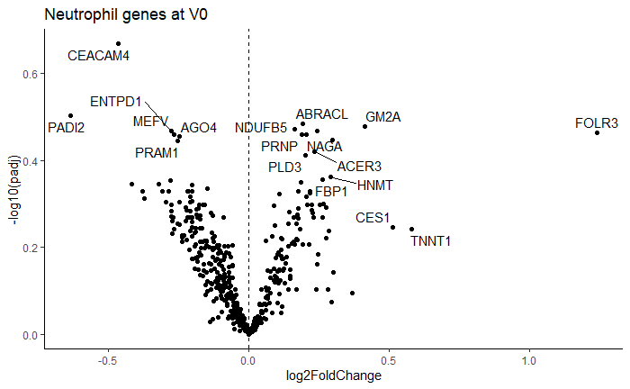

```r
ggplot(subset(res.df, external_gene_name %in% msigDB[[fgseaRes[[5, 'pathway']]]]), aes(x = log2FoldChange, y = -log10(padj), label = external_gene_name)) + geom_point() + geom_text_repel() + theme_classic() + ggtitle('Neutrophil genes at V0') + geom_vline(xintercept = 0, linetype = 2)
```

```r
btm = readRDS('data/Blood_Transcript_modules.RDS'); btm_annot = read_excel('data/btm_annotation_table.xls')
btm_annot = subset(btm_annot, `Module category` == 'immune'); btm = btm[c(btm_annot$ID)]; names(btm) = btm_annot$`Composite name`
fgseaRes = fgsea(pathways = btm, stats = ranks, nproc = 1); fgseaRes = fgseaRes[order(fgseaRes$padj, decreasing = FALSE), ]
```

An increased dendritic cell signature in the symptomatic group is found by FGSEA using both MSigDB and BTMs. [Takano et al. (2020)](https://doi.org/10.1016/j.xcrm.2022.100631) found that NK and dendritic cell migration occurs in the first day after Pfizer vaccination and correlates with local and systemic adverse events, suggesting that the increased BTM signature in this study may be predictive of this migration in the symptomatic group. V2 samples were collected 28 days after the second dose, and the increased blood NK signature suggests that these cells migrate back into the blood in the symptomatic group.

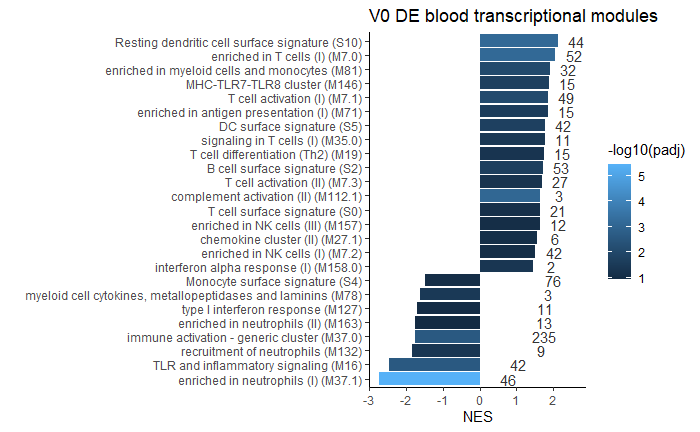

```r
write.csv(subset(fgseaRes, select = -c(leadingEdge)), file = 'results/fgseaRes_btm_immune_v0.csv', row.names = FALSE)

fgseaRes = fgseaRes[pathway %in% subset(btm_annot, `Module category` == 'immune')$`Composite name`, ]
ggplot(fgseaRes[1:25, ], aes(y = reorder(pathway, NES), x = NES, fill = -log10(padj), label = size)) + geom_col() + geom_text(color = 'gray20', nudge_x = ifelse(fgseaRes$NES > 0, 0.5, 3.5)) + ylab('') + theme_classic() + ggtitle('V0 DE blood transcriptional modules')
```

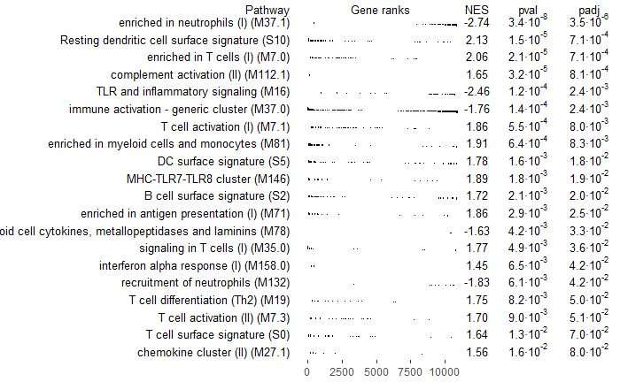

```r
plotGseaTable(btm[fgseaRes[1:20, ][, pathway]], ranks, fgseaRes[1:20, ], gseaParam = 0.5, colwidths = c(6, 3, 0.8, 1.2, 1.2), pathwayLabelStyle = list(size = 10), headerLabelStyle = list(size = 10), valueStyle = list(size = 10))
```

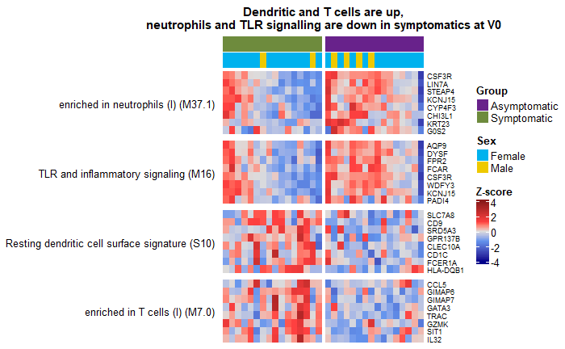

```r
res.df = res.df[order(res.df$log2FoldChange, decreasing = FALSE), ]
ha_top = HeatmapAnnotation(df = meta_data[, c('Group', 'Sex')], col = list(Group = c('Symptomatic' = 'darkolivegreen4', 'Asymptomatic' = 'darkorchid4'), Sex = c('Male' = 'gold2', 'Female' = 'deepskyblue2')), show_annotation_name = FALSE)
plot1 = vsd.df[rownames(subset(res.df, external_gene_name %in% btm[[fgseaRes[[1, 'pathway']]]] & log2FoldChange < 0))[1:8], ]
zzz = t(scale(t(plot1))); zzz = pmin(pmax(zzz, -3), 3); rownames(zzz) =  res.df[rownames(zzz), 'external_gene_name']
plot1 = Heatmap(zzz, row_title = fgseaRes[[1, 'pathway']], show_row_names = TRUE, show_column_names = FALSE, cluster_rows = TRUE, cluster_columns = TRUE, show_row_dend = FALSE, show_column_dend = FALSE, column_split = meta_data$Group, top_annotation = ha_top, heatmap_legend_param = list(title = "Z-score"), col = colorRamp2(c(-4, -1.25, 0, 1.25, 4), c("darkblue", "cornflowerblue", "gainsboro", "brown1", "firebrick4")), row_names_gp = gpar(fontsize = 7), row_title_rot = 0, row_title_gp = gpar(fontsize = 10), column_title_gp = gpar(fontsize = 11, fontface = 2), column_title = 'Dendritic and T cells are up,\nneutrophils and TLR signalling are down in symptomatics at V0')
plot2 = vsd.df[rownames(subset(res.df, external_gene_name %in% btm[[fgseaRes[[5, 'pathway']]]] & log2FoldChange < 0))[1:8], ]
zzz = t(scale(t(plot2))); zzz = pmin(pmax(zzz, -3), 3); rownames(zzz) =  res.df[rownames(zzz), 'external_gene_name']
plot2 = Heatmap(zzz, show_heatmap_legend = FALSE, row_title = fgseaRes[[5, 'pathway']], show_row_names = TRUE, show_column_names = FALSE, cluster_rows = TRUE, cluster_columns = TRUE, show_row_dend = FALSE, show_column_dend = FALSE, column_split = meta_data$Group, heatmap_legend_param = list(title = "Z-score"), col = colorRamp2(c(-4, -1.25, 0, 1.25, 4), c("darkblue", "cornflowerblue", "gainsboro", "brown1", "firebrick4")), row_names_gp = gpar(fontsize = 7), row_title_rot = 0, row_title_gp = gpar(fontsize = 10), column_title_gp = gpar(fontsize = 11, fontface = 2))
res.df = res.df[order(res.df$log2FoldChange, decreasing = TRUE), ]
plot3 = vsd.df[rownames(subset(res.df, external_gene_name %in% btm[[fgseaRes[[2, 'pathway']]]] & log2FoldChange > 0))[1:8], ]
zzz = t(scale(t(plot3))); zzz = pmin(pmax(zzz, -3), 3); rownames(zzz) =  res.df[rownames(zzz), 'external_gene_name']
plot3 = Heatmap(zzz, show_heatmap_legend = FALSE, row_title = fgseaRes[[2, 'pathway']], show_row_names = TRUE, show_column_names = FALSE, cluster_rows = TRUE, cluster_columns = TRUE, show_row_dend = FALSE, show_column_dend = FALSE, column_split = meta_data$Group, heatmap_legend_param = list(title = "Z-score"), col = colorRamp2(c(-4, -1.25, 0, 1.25, 4), c("darkblue", "cornflowerblue", "gainsboro", "brown1", "firebrick4")), row_names_gp = gpar(fontsize = 7), row_title_rot = 0, row_title_gp = gpar(fontsize = 10), column_title_gp = gpar(fontsize = 11, fontface = 2))
plot4 = vsd.df[rownames(subset(res.df, external_gene_name %in% btm[[fgseaRes[[3, 'pathway']]]] & log2FoldChange > 0))[1:8], ]
zzz = t(scale(t(plot4))); zzz = pmin(pmax(zzz, -3), 3); rownames(zzz) =  res.df[rownames(zzz), 'external_gene_name']
plot4 = Heatmap(zzz, show_heatmap_legend = FALSE, row_title = fgseaRes[[3, 'pathway']], show_row_names = TRUE, show_column_names = FALSE, cluster_rows = TRUE, cluster_columns = TRUE, show_row_dend = FALSE, show_column_dend = FALSE, column_split = meta_data$Group, heatmap_legend_param = list(title = "Z-score"), col = colorRamp2(c(-4, -1.25, 0, 1.25, 4), c("darkblue", "cornflowerblue", "gainsboro", "brown1", "firebrick4")), row_names_gp = gpar(fontsize = 7), row_title_rot = 0, row_title_gp = gpar(fontsize = 10), column_title_gp = gpar(fontsize = 11, fontface = 2))
draw(plot1 %v% plot2 %v% plot3 %v% plot4); rm(plot1); rm(plot2); rm(plot3); rm(plot4); rm(ha_top); rm(zzz); rm(ranks)
```

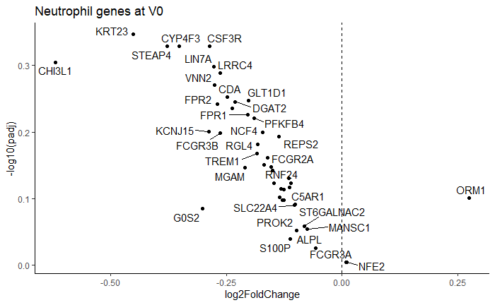

```r
ggplot(subset(res.df, external_gene_name %in% btm[[fgseaRes[[1, 'pathway']]]]), aes(x = log2FoldChange, y = -log10(padj), label = external_gene_name)) + geom_point() + geom_text_repel() + theme_classic() + ggtitle('Neutrophil genes at V0') + geom_vline(xintercept = 0, linetype = 2)
```

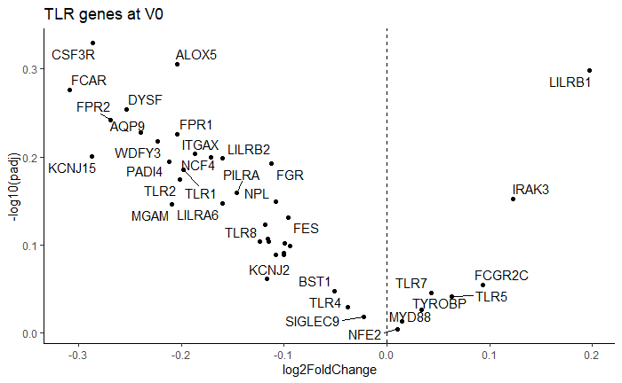

```r
ggplot(subset(res.df, external_gene_name %in% btm[[fgseaRes[[5, 'pathway']]]]), aes(x = log2FoldChange, y = -log10(padj), label = external_gene_name)) + geom_point() + geom_text_repel() + theme_classic() + ggtitle('TLR genes at V0') + geom_vline(xintercept = 0, linetype = 2)
```

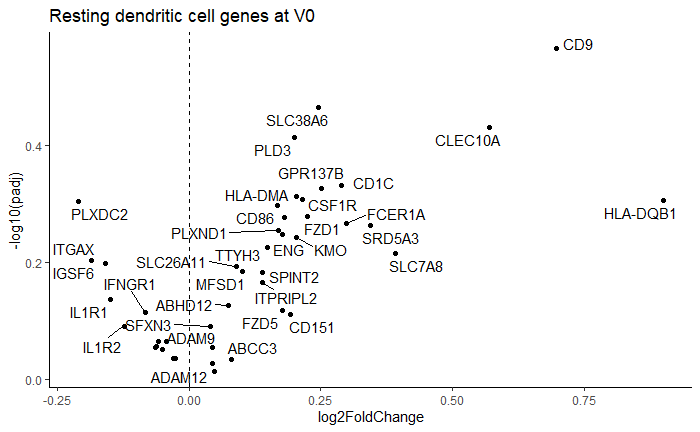

```r
ggplot(subset(res.df, external_gene_name %in% btm[[fgseaRes[[2, 'pathway']]]]), aes(x = log2FoldChange, y = -log10(padj), label = external_gene_name)) + geom_point() + geom_text_repel() + theme_classic() + ggtitle('Resting dendritic cell genes at V0') + geom_vline(xintercept = 0, linetype = 2)
```

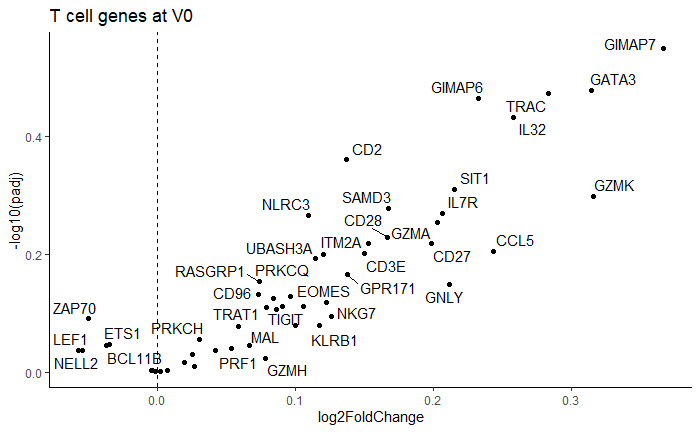

```r
ggplot(subset(res.df, external_gene_name %in% btm[[fgseaRes[[3, 'pathway']]]]), aes(x = log2FoldChange, y = -log10(padj), label = external_gene_name)) + geom_point() + geom_text_repel() + theme_classic() + ggtitle('T cell genes at V0') + geom_vline(xintercept = 0, linetype = 2)
```

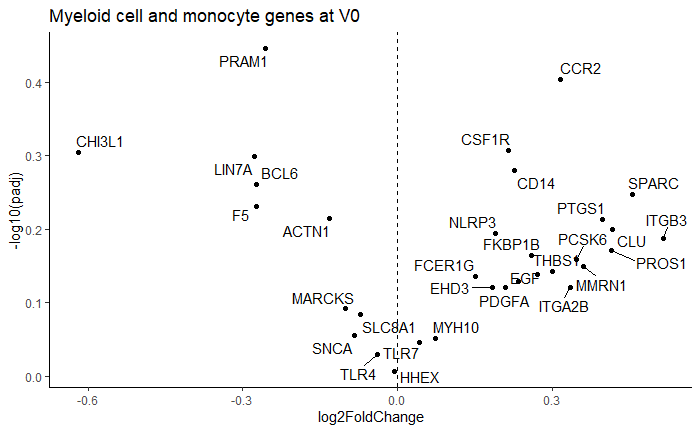

```r
ggplot(subset(res.df, external_gene_name %in% btm[[fgseaRes[[8, 'pathway']]]]), aes(x = log2FoldChange, y = -log10(padj), label = external_gene_name)) + geom_point() + geom_text_repel() + theme_classic() + ggtitle('Myeloid cell and monocyte genes at V0') + geom_vline(xintercept = 0, linetype = 2)
```